# Analyse der HaNS-Matomo-Daten

Author

Sebastian Sauer

Published

October 4, 2025

# 1 Hintergrund

Dieser Arbeitsbericht schildert das technische Vorgehen im Rahmen der Analyse der Matomo-Daten des BMBF-Projekt “HaNS”.

## 1.1 Vorgehen

Die Matomo-Klickdaten aller Semester der Projektlaufzeit wurden für diese Analyse verarbeitet. Mit Hilfe einer R-Pipeline wurden eine Reihe von Forschungsfragen analysiert.

Der komplette Code ist online dokumentiert unter https://github.com/sebastiansauer/hans. Aus Datenschutzgründen sind online keine Daten eingestellt.

Die zentrale Analyse-Pipeline-Datei ist https://github.com/sebastiansauer/hans/blob/main/_targets.R.

## 1.2 Forschungsfragen

1. Wie viele Nutzer gibt es und in welchem Zeitraum?
2. In welcher Frequenz wird HaNS aufgesucht? Wie groß sind die zeitlichen Zwischenräume zwischen der Benutzung der Plattform?
3. Wie oft wird HaNS pro Zeitraum (z.B. Monat) besucht?
4. Wie verändert sich die Nutzung im Zeitverlauf?
5. Wie viele Aktionen bringt ein Visit mit sich? Wie ist die statistische Verteilung der Aktionen pro Visit?
6. Wie lang verweilen die Nutzer pro Visit?
7. Wie verändert sich die Nutzungsdauer pro Visit im Zeitverlauf?
8. Welche Aktionen führen die Nutzer auf Hans aus?
9. Wie verändern sich die Verteilungen der Aktionshäufigkeiten im Zeitverlauf?
10. An welchen Tagen und zu welcher Zeit kommen die User zu HaNS?
11. Wie häufig und in welcher Art inteagieren die Nutzer mit dem LLM in HaNS?
12. Wie groß ist der Anteil der Nutzer, die mit dem LLM interagieren?
13. Wie verändert sich der Anteil der Nutzer, die mit dem LLM interagieren, im Zeitverlauf?
14. Wie oft wird auf ein Wort im Transkript des LLM geklickt?
15. Wie oft wird ein Transkript-Dienst in HaNS in Anspruch genommen?
16. Wie verändert sich die Nutzung der Transkript-Dienste in HaNS im Zeitverlauf?
17. Wie lange werden Videos angeschaut?
18. Wie verändert sich die Betrachtungsdauer im Zeitverlauf?

# 2 Setup

## 2.1 R-Pakete starten

```r
library(targets)
library(tidyverse)
library(ggokabeito)
library(easystats)
library(gt)
library(ggfittext)
library(scales)
library(visdat)
library(collapse)
library(ggpubr)
library(knitr)
library(tinytable)
library(data.table)
library(lubridate)
```

```r
library(ggplot2)
theme_set(theme_minimal())
```

## 2.2 Funktionen sourcen

## 2.3 Optionen setzen

```r
options(lubridate.week.start = 1) # Monday as first day
#options(collapse_mask = "all") # use collapse for all dplyr operations
options(chromote.headless = "new") # Chrome headleass needed for gtsave
```

```r
scale_colour_discrete <- function(...) scale_colour_brewer(palette = "Set2")
scale_fill_discrete <- function(...) scale_fill_brewer(palette = "Set2")
```

## 2.4 Daten laden

```r
tar_load(ai_transcript_clicks_per_month)
tar_load(config)
tar_load(course_and_uni_per_visit)
tar_load(data_all_fct)
tar_load(data_long)
tar_load(data_prepped)
tar_load(data_separated_distinct_slice)
tar_load(data_separated_filtered)
#tar_load(data_users_only)
tar_load(idvisit_has_llm)
tar_load(llm_response_text)
tar_load(n_action)
tar_load(n_action_type)
tar_load(n_action_w_date)
tar_load(time_duration)
tar_load(time_since_last_visit)
tar_load(time_spent)
tar_load(time_spent_w_course_university)
tar_load(time_visit_wday)
tar_load(n_mc_answers_selected)
tar_load(mc_answers_with_timestamps)
tar_load(n_action_fingerprint)
tar_load(time_visit_wday_fingerprint)
tar_load(n_action_w_date_fingerprint)
tar_load(time_spent_fingerprint)
tar_load(prompt_length)
tar_load(data_separated_filtered_date_uni_course)
```

# 3 Datenaufbereitung und Analysepipeline

## 3.1 Targets-Pipeline stellt Überblick aller Analyseschritte dar

Die Analyse wird im Rahmen einer [Targets-Pipeline](https://github.com/sebastiansauer/hans/blob/main/_targets.R) beschrieben und ist offen auf Github einsehbar.

## 3.2 Langformat

Aufgrund des “rechts flatternden” Datenformat (d.h. unterschiedliche Zeilenlängen) wurden die Daten in ein Langformat überführt, zwecks besserer/einfacherer Analyse.

Dazu wurden (neben den ID-Variablen, v.a. `idvisit`) die `actionDetails_`-Variablen verwendet. Der Code des Pivotierens in das Langformat ist in der Funktion longify-data.R einsehbar.

Die Daten im Langformat wurden dann noch etwas aufbereitet mt der Funktion [slimify-data.R](https://github.com/sebastiansauer/hans/blob/main/funs/slimify_data.R).

```r
data_separated_filtered |>
  head(30)
```

| nr | type | value | idvisit | fingerprint |
| --- | --- | --- | --- | --- |
| 0 | subtitle | https://hans.th-nuernberg.de/ | 1 | aa8a78771b4f21ff |
| 0 | timestamp | 2023-03-23 18:37:56 | 1 | aa8a78771b4f21ff |
| 1 | eventcategory | click_button | 1 | aa8a78771b4f21ff |
| 1 | eventaction | Medien | 1 | aa8a78771b4f21ff |
| 1 | timestamp | 2023-03-23 18:37:56 | 1 | aa8a78771b4f21ff |
| 1 | subtitle | Category: ""click_button', Action: ""Medien"" | 1 | aa8a78771b4f21ff |
| 2 | subtitle | https://hans.th-nuernberg.de/channels | 1 | aa8a78771b4f21ff |
| 2 | timestamp | 2023-03-23 18:37:59 | 1 | aa8a78771b4f21ff |
| 3 | eventcategory | click_button | 1 | aa8a78771b4f21ff |
| 3 | eventaction | Kanäle | 1 | aa8a78771b4f21ff |

[output cut: 20 more lines]

# 4 Überblick über die Daten

## 4.1 Roh-Daten laden und inspizieren (data_all_fact)

### 4.1.1 Dimension

Der Roh-Datensatz verfügt über

- 14207 Zeilen
- 3181 Spalten (Dubletten und Spalten mit Bildern bereits entfernt)

Jede Zeile entspricht einem “Visit”.

### 4.1.2 Erster Blick

```r
data_all_fct_head100 <-
  data_all_fct %>%
  select(1:100) %>%
  slice_head(n = 100)
```

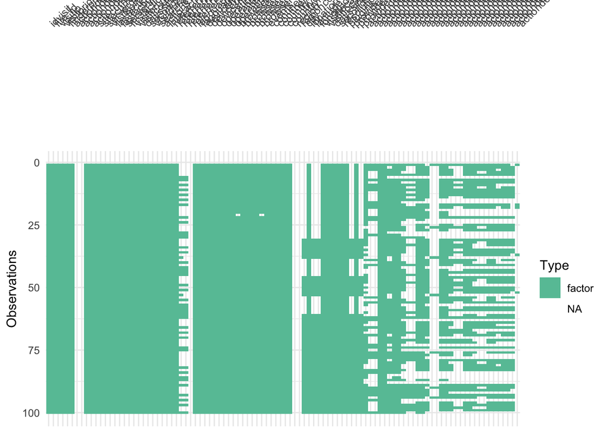

```r
data_all_fct_head100 %>%
  visdat::vis_dat()
```

### 4.1.3 (Fast) leere Spalten

```r
d_na_cols <- data.frame(
  id = 1:ncol(data_all_fct),
  names = names(data_all_fct),
  na_prop = colMeans(is.na(data_all_fct))
)
```

#### 4.1.3.1 Leere Spalten

```r
d_na_cols |>
  filter(na_prop == 1)
```

|  | id | names | na_prop |
| --- | --- | --- | --- |
| actiondetails_0_sitesearchkeyword | 7 | actiondetails_0_sitesearchkeyword | 1 |
| actiondetails_0_sitesearchcount | 8 | actiondetails_0_sitesearchcount | 1 |
| actiondetails_257_sitesearchkeyword | 2914 | actiondetails_257_sitesearchkeyword | 1 |
| actiondetails_257_sitesearchcount | 2915 | actiondetails_257_sitesearchcount | 1 |
| actiondetails_193_sitesearchkeyword | 2924 | actiondetails_193_sitesearchkeyword | 1 |
| actiondetails_193_sitesearchcount | 2925 | actiondetails_193_sitesearchcount | 1 |
| actiondetails_322_sitesearchkeyword | 2934 | actiondetails_322_sitesearchkeyword | 1 |
| actiondetails_322_sitesearchcount | 2935 | actiondetails_322_sitesearchcount | 1 |
|  | 2992 |  | 1 |
| actiondetails_267_sitesearchkeyword | 3005 | actiondetails_267_sitesearchkeyword | 1 |

[output cut: 5 more lines]

#### 4.1.3.2 Fast leere Spalten

```r
no_na_cols <-
  d_na_cols |>
  filter(na_prop > .9) |>
  nrow()

no_na_cols
```

```
[1] 1951
```

**Important**

Sehr viele Spalten, 1951 sind fast leer.

### 4.1.4 Namen (1-100)

```r
d_100_names <- data.frame(
  id = 1:100,
  col_name = data_all_fct_head100 %>% names()
)

d_100_names
```

| id | col_name |
| --- | --- |
| 1 | idvisit |
| 2 | file_id |
| 3 | visitip |
| 4 | visitorid |
| 5 | fingerprint |
| 6 | actiondetails_0_url |
| 7 | actiondetails_0_sitesearchkeyword |
| 8 | actiondetails_0_sitesearchcount |
| 9 | actiondetails_0_subtitle |
| 10 | actiondetails_0_timestamp |

[output cut: 90 more lines]

### 4.1.5 Werte der erst 100 Spalten

```r
data_all_fct_head100
```

| idvisit | file_id | visitip | visitorid | fingerprint | actiondetails_0_type | actiondetails_0_url | actiondetails_0_sitesearchkeyword | actiondetails_0_sitesearchcount | actiondetails_0_title | actiondetails_0_subtitle | actiondetails_0_timestamp | sitecurrency | sitecurrencysymbol | serverdate | visitserverhour | lastactiontimestamp | lastactiondatetime | servertimestamp | firstactiontimestamp | visitortype | visitcount | dayssincefirstvisit | secondssincefirstvisit | visitduration | searches | actions | interactions | referrertype | referrertypename | … |
| --- | --- | --- | --- | --- | --- | --- | --- | --- | --- | --- | --- | --- | --- | --- | --- | --- | --- | --- | --- | --- | --- | --- | --- | --- | --- | --- | --- | --- | --- | --- |
| 1 | matomo_export_2023-03-23.csv | 217.85.0.0 | 222edbe56ec28397 | aa8a78771b4f21ff | action | https://hans.th-nuernberg.de/ | NA | NA | HAnS | https://hans.th-nuernberg.de/ | 2023-03-23 18:37:56 | USD | $ | 2023-03-23 | 18 | 2023-03-23 18:02:49 | 2023-03-23 18:02:49 | 2023-03-23 18:02:49 | 2023-03-23 17:37:56 | returning | 4 | 0 | 15464 | 1494 | 7 | 158 | 38 | direct | Direct Entry | … |
| 2 | matomo_export_2023-03-23.csv | 217.85.0.0 | 222edbe56ec28397 | aa8a78771b4f21ff | action | https://hans.th-nuernberg.de/channels | NA | NA | HAnS | https://hans.th-nuernberg.de/channels | 2023-03-23 17:18:10 | USD | $ | 2023-03-23 | 17 | 2023-03-23 17:00:44 | 2023-03-23 17:00:44 | 2023-03-23 17:00:44 | 2023-03-23 16:18:10 | returning | 3 | 0 | 10678 | 2555 | 2 | 12 | 7 | direct | Direct Entry | … |
| 3 | matomo_export_2023-03-23.csv | 141.75.0.0 | 1ddd5dfacfa787a4 | 1f026ad3cbbdf325 | action | https://hans.th-nuernberg.de/ | NA | NA | HAnS | https://hans.th-nuernberg.de/ | 2023-03-23 17:17:36 | USD | $ | 2023-03-23 | 16 | 2023-03-23 16:18:54 | 2023-03-23 16:18:54 | 2023-03-23 16:18:54 | 2023-03-23 16:17:36 | new | 1 | 0 | 0 | 79 | 1 | 9 | 5 | direct | Direct Entry | … |
| 4 | matomo_export_2023-03-23.csv | 217.85.0.0 | 222edbe56ec28397 | aa8a78771b4f21ff | event | https://hans.th-nuernberg.de/ | NA | NA | Event | Category: ""click_button', Action: ""Kanäle"" | 2023-03-23 15:15:59 | USD | $ | 2023-03-23 | 15 | 2023-03-23 15:47:17 | 2023-03-23 15:47:17 | 2023-03-23 15:47:17 | 2023-03-23 14:15:59 | returning | 2 | 0 | 3347 | 5479 | 9 | 108 | 52 | direct | Direct Entry | … |
| 5 | matomo_export_2023-03-23.csv | 217.85.0.0 | 74773ced8f01a582 | aa8a78771b4f21ff | action | https://hans.th-nuernberg.de/login | NA | NA | HAnS | https://hans.th-nuernberg.de/login | 2023-03-23 14:20:12 | USD | $ | 2023-03-23 | 13 | 2023-03-23 13:37:45 | 2023-03-23 13:37:45 | 2023-03-23 13:37:45 | 2023-03-23 13:20:12 | new | 1 | 0 | 0 | 1054 | 0 | 25 | 13 | direct | Direct Entry | … |
| 6 | matomo_export_2023-03-23.csv | 31.16.0.0 | d7efc2b1d308e9d6 | 518965d4e1ae7e2d | action | https://hans.th-nuernberg.de/login | NA | NA | HAnS | https://hans.th-nuernberg.de/login | 2023-03-23 14:29:42 | USD | $ | 2023-03-23 | 13 | 2023-03-23 13:31:36 | 2023-03-23 13:31:36 | 2023-03-23 13:31:36 | 2023-03-23 13:29:42 | new | 1 | 0 | 0 | 115 | 0 | 2 | 2 | website | Websites | … |
| 7 | matomo_export_2023-03-24.csv | 217.84.0.0 | c77ae8b840d8aba9 | aa957061ec277742 | event | https://hans.th-nuernberg.de/video-player?uuid=d7d95ab4-ffdf-4465-9823-38289f147b74 | NA | NA | Event | Category: ""videoplayer_click', Action: ""play"" | 2023-03-24 17:58:33 | USD | $ | 2023-03-24 | 17 | 2023-03-24 17:33:17 | 2023-03-24 17:33:17 | 2023-03-24 17:33:17 | 2023-03-24 16:58:33 | returning | 5 | 0 | 75423 | 2085 | 0 | 13 | 0 | website | Websites | … |
| 8 | matomo_export_2023-03-24.csv | 141.75.0.0 | 1564fdddf996ae28 | e89126eaae40660e | event | https://hans.th-nuernberg.de/video-player?uuid=c79209da-d1b7-4048-9623-133d5def7d94 | NA | NA | Event | Category: ""click_button', Action: ""Kanäle"" | 2023-03-24 16:06:55 | USD | $ | 2023-03-24 | 15 | 2023-03-24 15:33:48 | 2023-03-24 15:33:48 | 2023-03-24 15:33:48 | 2023-03-24 15:06:55 | returning | 2 | 0 | 22139 | 1614 | 1 | 11 | 3 | direct | Direct Entry | … |
| 9 | matomo_export_2023-03-24.csv | 217.84.0.0 | c77ae8b840d8aba9 | aa957061ec277742 | event | https://hans.th-nuernberg.de/video-player?uuid=d7d95ab4-ffdf-4465-9823-38289f147b74 | NA | NA | Event | Category: ""videoplayer_click', Action: ""play"" | 2023-03-24 16:21:10 | USD | $ | 2023-03-24 | 15 | 2023-03-24 15:26:44 | 2023-03-24 15:26:44 | 2023-03-24 15:26:44 | 2023-03-24 15:21:10 | returning | 4 | 0 | 69580 | 335 | 0 | 7 | 0 | website | Websites | … |
| 10 | matomo_export_2023-03-24.csv | 141.75.0.0 | 222edbe56ec28397 | 14e1d60a5ac559aa | action | https://hans.th-nuernberg.de/channels | NA | NA | HAnS | https://hans.th-nuernberg.de/channels | 2023-03-24 15:30:36 | USD | $ | 2023-03-24 | 15 | 2023-03-24 15:20:47 | 2023-03-24 15:20:47 | 2023-03-24 15:20:47 | 2023-03-24 14:30:36 | returning | 8 | 1 | 90624 | 3012 | 12 | 61 | 31 | direct | Direct Entry | … |

[output cut: 90 more lines]

### 4.1.6 Datensatz data_separated_filtered, Zeilen 1-100

```r
data_separated_filtered %>%
  slice(1:100)
```

| nr | type | value | idvisit | fingerprint |
| --- | --- | --- | --- | --- |
| 0 | subtitle | https://hans.th-nuernberg.de/ | 1 | aa8a78771b4f21ff |
| 0 | timestamp | 2023-03-23 18:37:56 | 1 | aa8a78771b4f21ff |
| 1 | eventcategory | click_button | 1 | aa8a78771b4f21ff |
| 1 | eventaction | Medien | 1 | aa8a78771b4f21ff |
| 1 | timestamp | 2023-03-23 18:37:56 | 1 | aa8a78771b4f21ff |
| 1 | subtitle | Category: ""click_button', Action: ""Medien"" | 1 | aa8a78771b4f21ff |
| 2 | subtitle | https://hans.th-nuernberg.de/channels | 1 | aa8a78771b4f21ff |
| 2 | timestamp | 2023-03-23 18:37:59 | 1 | aa8a78771b4f21ff |
| 3 | eventcategory | click_button | 1 | aa8a78771b4f21ff |
| 3 | eventaction | Kanäle | 1 | aa8a78771b4f21ff |

[output cut: 90 more lines]

## 4.2 Fallzahl im Nur-User-Datensatz

- 14207 Zeilen
- 3181 Spalten

## 4.3 Datensatz mit Anzahl der Aktionen pro User

### 4.3.1 idvisit

```r
n_action |> dim()
```

```
[1] 14207     2
```

```r
n_action |>
  head(30)
```

| idvisit | nr_max |
| --- | --- |
| 1 | 157 |
| 2 | 11 |
| 3 | 8 |
| 4 | 107 |
| 5 | 24 |
| 6 | 1 |
| 7 | 12 |
| 8 | 10 |
| 9 | 6 |
| 10 | 60 |

[output cut: 20 more lines]

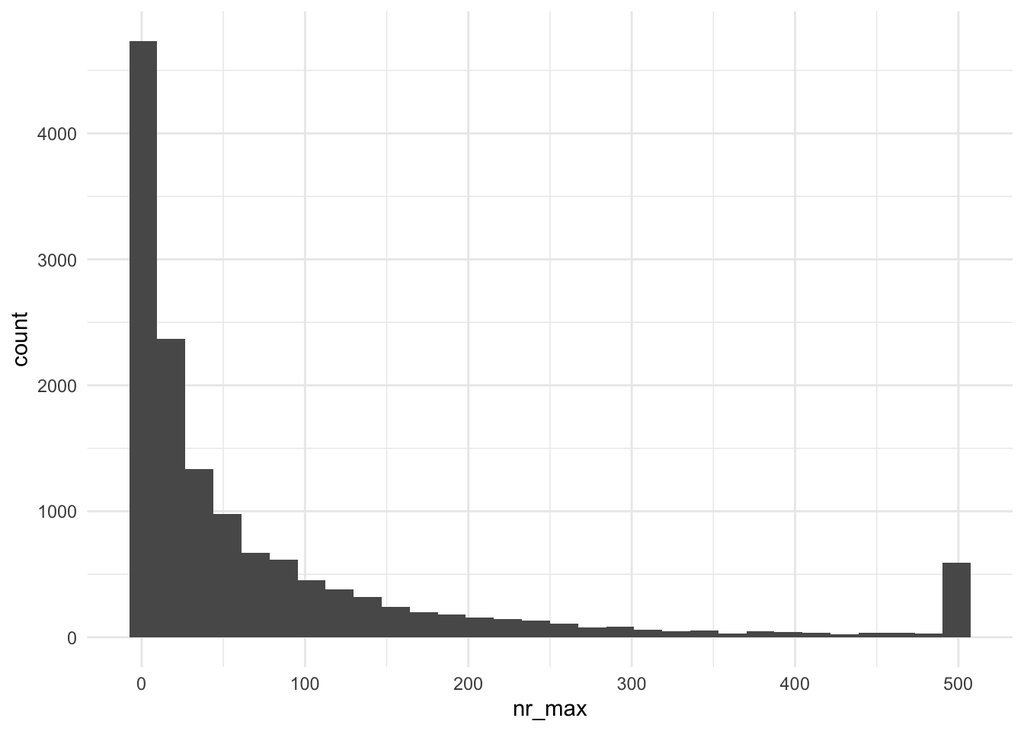

```r
n_action |>
  ggplot(aes(x = nr_max)) +
  geom_histogram()
```

### 4.3.2 fingerprint

```r
n_action_fingerprint |> head(30)
```

| fingerprint | nr_max |
| --- | --- |
| 000ca9d4f0528942 | 13 |
| 0018db5635d12642 | 63 |
| 001a970cf1c5af5c | 499 |
| 001bafb0842a51f4 | 4 |
| 0022c1e3c648d3af | 4 |
| 002f64c72dfb2311 | 26 |
| 00401c73402d3bd1 | 1 |
| 0040967a8dc45943 | 192 |
| 0048b22ae4713b32 | 3 |
| 004b6fdaf60254d7 | 13 |

[output cut: 20 more lines]

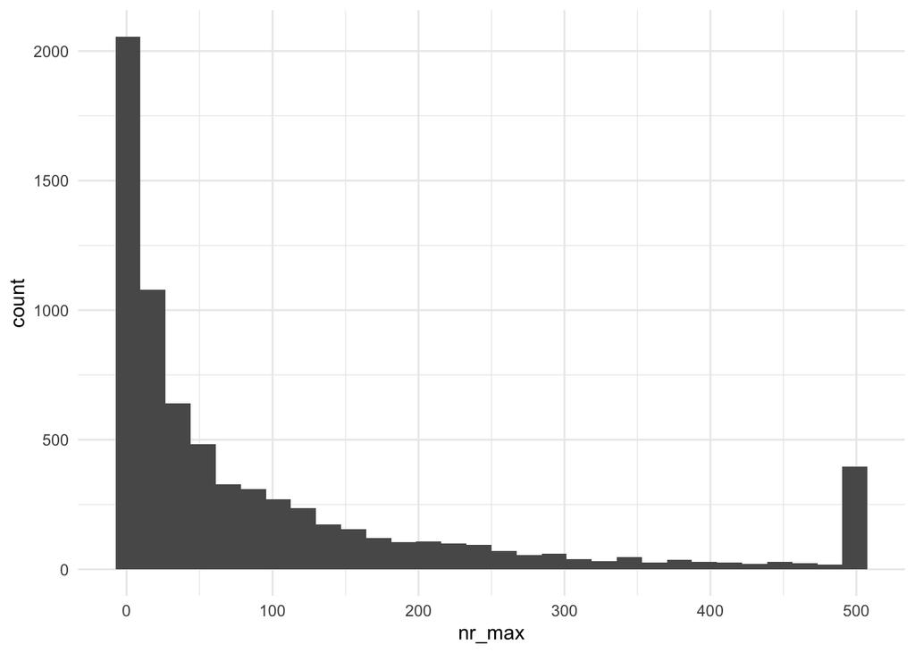

```r
n_action_fingerprint |>
  ggplot(aes(x = nr_max)) +
  geom_histogram()
```

# 5 Zeitraum

## 5.1 Beginn/Ende der Daten

```r
n_action_w_date |>
  head(30)
```

| idvisit | nr_max | date_time_start | month_of_visit | month_date | week_date | week_of_visit | year_of_visit | hour_of_visit_start |
| --- | --- | --- | --- | --- | --- | --- | --- | --- |
| 1 | 157 | 2023-03-23 18:37:56 | Mar | 2023-03-01 | 2023-03-20 | 12 | 2023 | 18 |
| 2 | 11 | 2023-03-23 17:18:10 | Mar | 2023-03-01 | 2023-03-20 | 12 | 2023 | 17 |
| 3 | 8 | 2023-03-23 17:17:36 | Mar | 2023-03-01 | 2023-03-20 | 12 | 2023 | 17 |
| 4 | 107 | 2023-03-23 15:15:59 | Mar | 2023-03-01 | 2023-03-20 | 12 | 2023 | 15 |
| 5 | 24 | 2023-03-23 14:20:12 | Mar | 2023-03-01 | 2023-03-20 | 12 | 2023 | 14 |
| 6 | 1 | 2023-03-23 14:29:42 | Mar | 2023-03-01 | 2023-03-20 | 12 | 2023 | 14 |
| 7 | 12 | 2023-03-24 17:58:33 | Mar | 2023-03-01 | 2023-03-20 | 12 | 2023 | 17 |
| 8 | 10 | 2023-03-24 16:06:55 | Mar | 2023-03-01 | 2023-03-20 | 12 | 2023 | 16 |
| 9 | 6 | 2023-03-24 16:21:10 | Mar | 2023-03-01 | 2023-03-20 | 12 | 2023 | 16 |
| 10 | 60 | 2023-03-24 15:30:36 | Mar | 2023-03-01 | 2023-03-20 | 12 | 2023 | 15 |

[output cut: 20 more lines]

```r
min_max_time <-
  n_action_w_date |>
  summarise(
    time_min = min(date_time_start, na.rm = T),
    time_max = max(date_time_start, na.rm = T)
  )

min_max_time |>
  gt()
```

| time_min | time_max |
| --- | --- |
| 2022-12-05 15:33:45 | 2025-07-14 23:40:45 |

**Important**

Erster Visit im Datensatz: 2022-12-05 15:33:45.

Letzter Visit im Datensatz: 2025-07-14 23:40:45.

Diese Statistik wurde auf Basis des Datenobjekts `data_separated_filtered` berechnet, vgl. [das Target dieses Objekts in der Pipeline](https://github.com/sebastiansauer/hans/blob/main/_targets.R#L170).

## 5.2 Days since last visit

### 5.2.1 Insgesamt

#### 5.2.1.1 idvisit

```r
time_visit_wday |>
  head(30)
```

| idvisit | dow | hour | date_time |
| --- | --- | --- | --- |
| 1 | 4 | 18 | 2023-03-23 18:37:56 |
| 2 | 4 | 17 | 2023-03-23 17:18:10 |
| 3 | 4 | 17 | 2023-03-23 17:17:36 |
| 4 | 4 | 15 | 2023-03-23 15:15:59 |
| 5 | 4 | 14 | 2023-03-23 14:20:12 |
| 6 | 4 | 14 | 2023-03-23 14:29:42 |
| 7 | 5 | 17 | 2023-03-24 17:58:33 |
| 8 | 5 | 16 | 2023-03-24 16:06:55 |
| 9 | 5 | 16 | 2023-03-24 16:21:10 |
| 10 | 5 | 15 | 2023-03-24 15:30:36 |

[output cut: 20 more lines]

```r
time_since_last_visit <-
  time_since_last_visit |>
  mutate(dayssincelastvisit = as.numeric(dayssincelastvisit)) |>
  distinct(idvisit, .keep_all = TRUE)

time_since_last_visit |>
  datawizard::describe_distribution(dayssincelastvisit) |>
  knitr::kable(digits = 2)
```

| Variable | Mean | SD | IQR | Min | Max | Skewness | Kurtosis | n | n_Missing |
| --- | --- | --- | --- | --- | --- | --- | --- | --- | --- |
| dayssincelastvisit | 6.89 | 15.75 | 0 | 1 | 87 | 2.98 | 8.26 | 14207 | 0 |

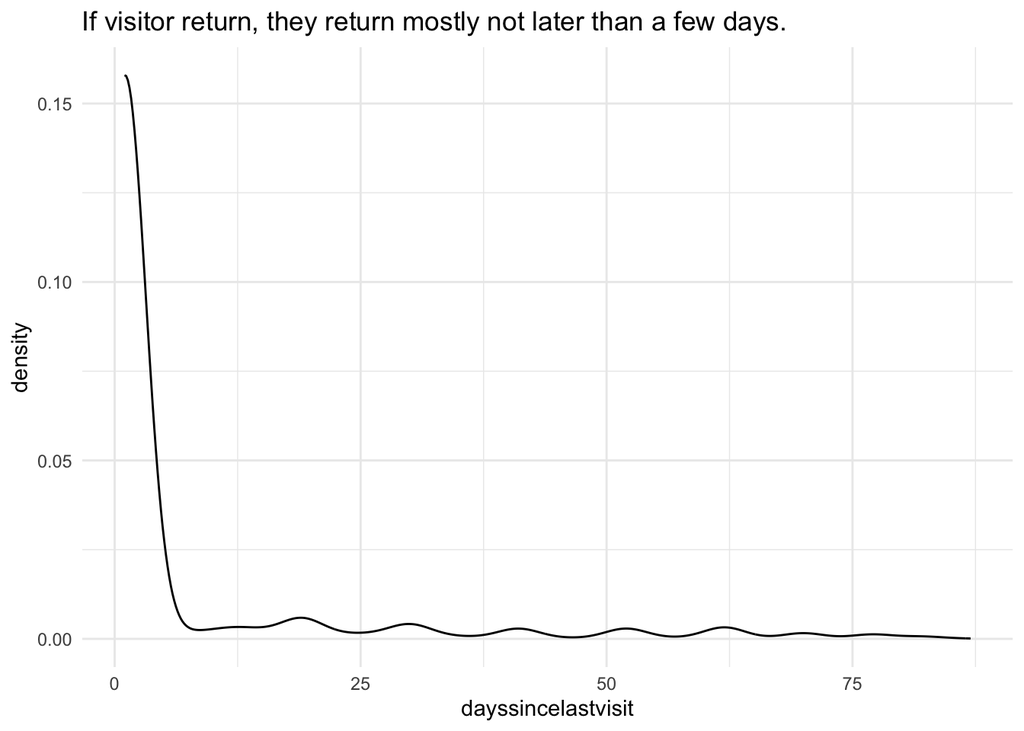

```r
time_since_last_visit |>
  ggplot(aes(x = dayssincelastvisit)) +
  geom_density() +
  labs(
    title = "If visitor return, they return mostly not later than a few days."
  )
```

**Important**

Die Nutzer nutzen die Seite in Abständen von wenigen Tagen?

#### 5.2.1.2 fingerprint unique

```r
time_visit_wday_fingerprint |> head()
```

| fingerprint | dow | hour | date_time |
| --- | --- | --- | --- |
| aa8a78771b4f21ff | 4 | 18 | 2023-03-23 18:37:56 |
| 1f026ad3cbbdf325 | 4 | 17 | 2023-03-23 17:17:36 |
| 518965d4e1ae7e2d | 4 | 14 | 2023-03-23 14:29:42 |
| aa957061ec277742 | 5 | 17 | 2023-03-24 17:58:33 |
| e89126eaae40660e | 5 | 16 | 2023-03-24 16:06:55 |
| 14e1d60a5ac559aa | 5 | 15 | 2023-03-24 15:30:36 |

```r
time_since_last_visit_fingerprint <-
  time_since_last_visit |>
  mutate(dayssincelastvisit = as.numeric(dayssincelastvisit)) |>
  distinct(fingerprint, .keep_all = TRUE)

time_since_last_visit |>
  datawizard::describe_distribution(dayssincelastvisit) |>
  knitr::kable(digits = 2)
```

| Variable | Mean | SD | IQR | Min | Max | Skewness | Kurtosis | n | n_Missing |
| --- | --- | --- | --- | --- | --- | --- | --- | --- | --- |
| dayssincelastvisit | 6.89 | 15.75 | 0 | 1 | 87 | 2.98 | 8.26 | 14207 | 0 |

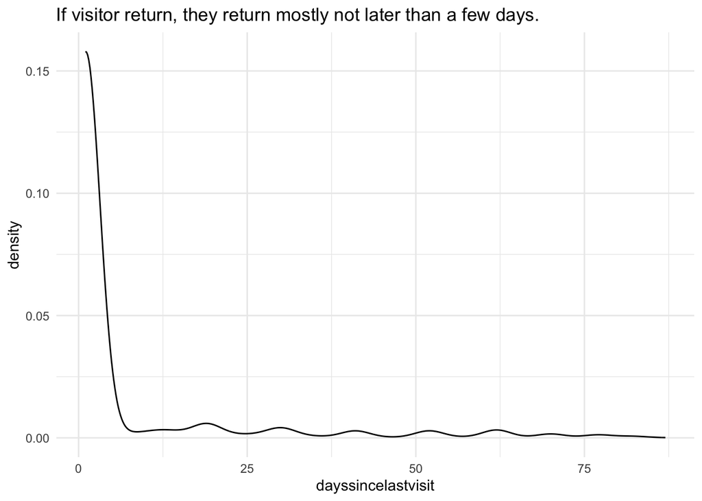

```r
time_since_last_visit |>
  ggplot(aes(x = dayssincelastvisit)) +
  geom_density() +
  labs(
    title = "If visitor return, they return mostly not later than a few days."
  )
```

### 5.2.2 Nach Lehrveranstaltungen

```r
time_since_last_visit_per_course <-
  time_since_last_visit |>
  left_join(course_and_uni_per_visit) |>
  drop_na()
```

```r
time_since_last_visit_per_course_summary <-
  time_since_last_visit_per_course |>
  group_by(course) |>
  summarise(
    dayssincelastvisit_mean = mean(dayssincelastvisit),
    dayssincelastvisit_sd = sd(dayssincelastvisit),
    dayssincelastvisit_n = n()
  ) |>
  mutate(
    dayssincelastvisit_n_log = log(dayssincelastvisit_n, base = 10) + 0.001
  )
```

```r
time_since_last_visit_per_course_summary
```

| course | dayssincelastvisit_mean | dayssincelastvisit_sd | dayssincelastvisit_n | dayssincelastvisit_n_log |
| --- | --- | --- | --- | --- |
| anis2 | 2.7209302 | 6.370787 | 43 | 1.6344685 |
| armeufa | 0.0000000 | 0.000000 | 2 | 0.3020300 |
| bare | 11.0769231 | 16.311864 | 13 | 1.1149434 |
| bio | 1.8511905 | 6.427523 | 168 | 2.2263093 |
| biotech | 2.0236220 | 8.448222 | 127 | 2.1048037 |
| biovete | 1.2418033 | 4.414125 | 244 | 2.3883898 |
| cta1 | 2.0261497 | 5.814851 | 1109 | 3.0459315 |
| daba | 3.3080808 | 7.097654 | 198 | 2.2976652 |
| enerbi | 3.9000000 | 6.951419 | 10 | 1.0010000 |
| epsy | 16.0000000 | NA | 1 | 0.0010000 |

[output cut: 18 more lines]

[figure not shown]

```r
time_since_last_visit_per_course_summary |>
  ggplot(aes(
    y = reorder(course, dayssincelastvisit_mean),
    x = dayssincelastvisit_mean
  )) +
  geom_errorbar(aes(
    xmin = dayssincelastvisit_mean - dayssincelastvisit_sd,
    xmax = dayssincelastvisit_mean + dayssincelastvisit_sd
  )) +
  geom_point(aes(alpha = log(dayssincelastvisit_n)), show.legend = FALSE) +
  labs(
    x = "Days since last visit (mean±sd)",
    y = "course",
    title = "In some courses, users use HaNS frequently.",
    caption = "Grey saturation of the mean dots refers to the log10 of the sample size (N)"
  ) +
  geom_text(
    aes(label = round(dayssincelastvisit_n)),
    x = Inf,
    hjust = 1.2,
    size = 2
  ) +
  annotate(
    x = Inf,
    y = Inf,
    label = "N",
    geom = "label",
    hjust = 1,
    vjust = 1
  ) +
  scale_y_discrete(expand = expansion(mult = 0.1)) +
  theme_minimal()
```

## 5.3 Visits im Zeitverlauf

Wie viele Visits (von Hans) gab es?

### 5.3.1 Pro Monat

#### 5.3.1.1 idivisit

```r
time_visit_wday_summary <-
  time_visit_wday |>
  ungroup() |>
  mutate(month_start = floor_date(date_time, "month")) |>
  mutate(
    month_name = lubridate::month(date_time, label = TRUE, abbr = FALSE),
    month_num = lubridate::month(date_time, label = FALSE),
    year_num = lubridate::year(date_time)
  )
```

```r
time_visit_wday_summary |>
  group_by(year_num, month_num) |>
  summarise(n = n()) |>
  gt()
```

| month_num | n |
| --- | --- |
| 2022 |  |
| 12 | 329 |
| 2023 |  |
| 1 | 455 |
| 2 | 561 |
| 3 | 149 |
| 4 | 253 |
| 5 | 391 |
| 6 | 292 |
| 7 | 441 |
| 8 | 26 |
| 9 | 39 |
| 10 | 614 |
| 11 | 660 |
| 12 | 519 |
| 2024 |  |
| 1 | 783 |
| 2 | 85 |
| 3 | 138 |
| 4 | 329 |
| 5 | 413 |
| 6 | 593 |
| 7 | 743 |
| 8 | 16 |
| 9 | 23 |
| 10 | 731 |
| 11 | 918 |
| 12 | 765 |
| 2025 |  |
| 1 | 959 |
| 2 | 155 |
| 3 | 507 |
| 4 | 1011 |
| 5 | 557 |
| 6 | 321 |
| 7 | 430 |
| NA |  |
| NA | 1 |

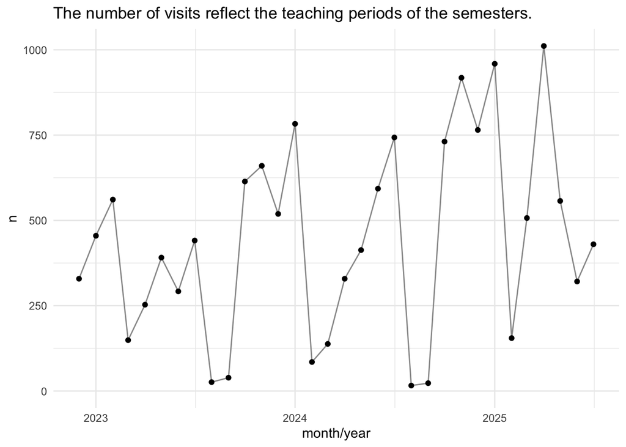

```r
time_visit_wday_summary |>
  group_by(year_num, month_start) |>
  summarise(n = n()) |>
  ggplot(aes(x = month_start, y = n)) +
  geom_line(group = 1, color = "grey60") +
  geom_point() +
  labs(
    title = "The number of visits reflect the teaching periods of the semesters.",
    x = "month/year"
  )
```

#### 5.3.1.2 fingerprint

```r
time_visit_wday_summary_fingerprint <-
  time_visit_wday_fingerprint |>
  ungroup() |>
  mutate(month_start = floor_date(date_time, "month")) |>
  mutate(
    month_name = lubridate::month(date_time, label = TRUE, abbr = FALSE),
    month_num = lubridate::month(date_time),
    year_num = lubridate::year(date_time)
  )
```

```r
time_visit_wday_summary_fingerprint |>
  group_by(year_num, month_num) |>
  summarise(n = n()) |>
  gt()
```

| month_num | n |
| --- | --- |
| 2022 |  |
| 12 | 235 |
| 2023 |  |
| 1 | 248 |
| 2 | 303 |
| 3 | 99 |
| 4 | 160 |
| 5 | 226 |
| 6 | 195 |
| 7 | 227 |
| 8 | 17 |
| 9 | 23 |
| 10 | 402 |
| 11 | 412 |
| 12 | 325 |
| 2024 |  |
| 1 | 445 |
| 2 | 50 |
| 3 | 94 |
| 4 | 179 |
| 5 | 204 |
| 6 | 274 |
| 7 | 214 |
| 8 | 10 |
| 9 | 16 |
| 10 | 365 |
| 11 | 417 |
| 12 | 317 |
| 2025 |  |
| 1 | 347 |
| 2 | 74 |
| 3 | 217 |
| 4 | 424 |
| 5 | 273 |
| 6 | 171 |
| 7 | 196 |
| NA |  |
| NA | 1 |

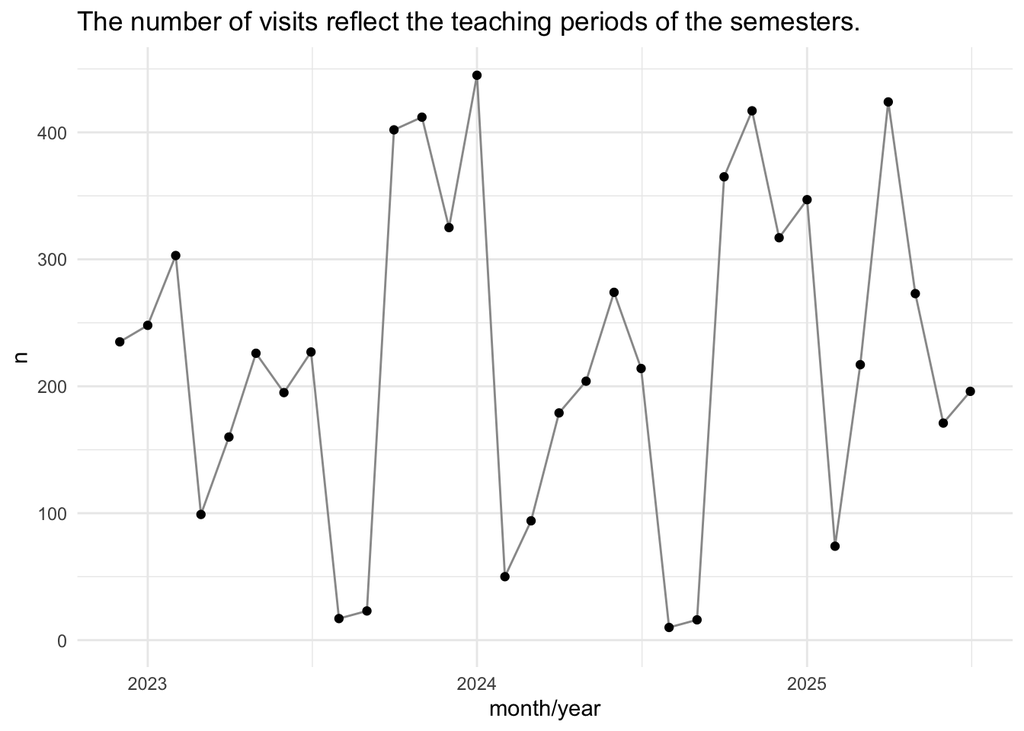

```r
time_visit_wday_summary_fingerprint |>
  group_by(year_num, month_start) |>
  summarise(n = n()) |>
  ggplot(aes(x = month_start, y = n)) +
  geom_line(group = 1, color = "grey60") +
  geom_point() +
  labs(
    title = "The number of visits reflect the teaching periods of the semesters.",
    x = "month/year"
  )
```

#### 5.3.1.3 fingerprint unique

```r
time_visit_wday_summary_fingerprint_unique <-
  time_visit_wday_fingerprint |>
  ungroup() |>
  distinct(fingerprint, .keep_all = TRUE) |>
  mutate(month_start = floor_date(date_time, "month")) |>
  mutate(
    month_name = lubridate::month(date_time, label = TRUE, abbr = FALSE),
    month_num = lubridate::month(date_time),
    year_num = lubridate::year(date_time)
  )
```

```r
time_visit_wday_summary_fingerprint_unique |>
  group_by(year_num, month_num) |>
  summarise(n = n()) |>
  gt()
```

| month_num | n |
| --- | --- |
| 2022 |  |
| 12 | 235 |
| 2023 |  |
| 1 | 248 |
| 2 | 303 |
| 3 | 99 |
| 4 | 160 |
| 5 | 226 |
| 6 | 195 |
| 7 | 227 |
| 8 | 17 |
| 9 | 23 |
| 10 | 402 |
| 11 | 412 |
| 12 | 325 |
| 2024 |  |
| 1 | 445 |
| 2 | 50 |
| 3 | 94 |
| 4 | 179 |
| 5 | 204 |
| 6 | 274 |
| 7 | 214 |
| 8 | 10 |
| 9 | 16 |
| 10 | 365 |
| 11 | 417 |
| 12 | 317 |
| 2025 |  |
| 1 | 347 |
| 2 | 74 |
| 3 | 217 |
| 4 | 424 |
| 5 | 273 |
| 6 | 171 |
| 7 | 196 |
| NA |  |
| NA | 1 |

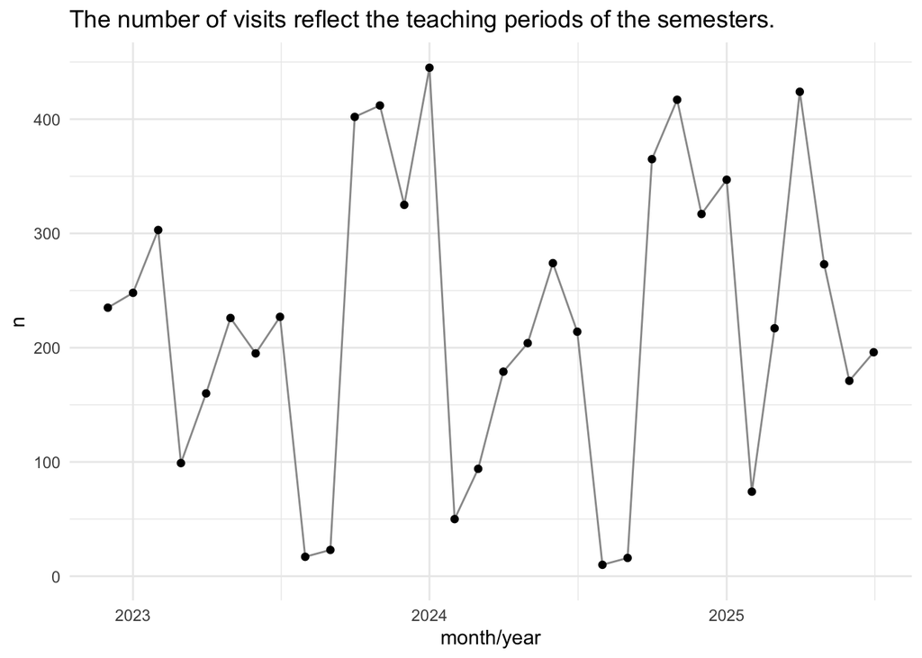

```r
time_visit_wday_summary_fingerprint_unique |>
  group_by(year_num, month_start) |>
  summarise(n = n()) |>
  ggplot(aes(x = month_start, y = n)) +
  geom_line(group = 1, color = "grey60") +
  geom_point() +
  labs(
    title = "The number of visits reflect the teaching periods of the semesters.",
    x = "month/year"
  )
```

### 5.3.2 Pro Woche

```r
time_visit_wday_summary_week <-
  time_visit_wday |>
  ungroup() |>
  mutate(week_start = floor_date(date_time, "week")) |>
  mutate(week_num = week(date_time), year_num = year(date_time))
```

```r
time_visit_wday_summary_week_summarized <-
  time_visit_wday_summary_week |>
  group_by(year_num, week_num) |>
  summarise(n = n())

time_visit_wday_summary_week_summarized
```

| year_num | week_num | n |
| --- | --- | --- |
| 2022 | 49 | 79 |
| 2022 | 50 | 117 |
| 2022 | 51 | 79 |
| 2022 | 52 | 51 |
| 2022 | 53 | 3 |
| 2023 | 1 | 63 |
| 2023 | 2 | 87 |
| 2023 | 3 | 123 |
| 2023 | 4 | 95 |
| 2023 | 5 | 442 |

[output cut: 128 more lines]

```r
time_visit_wday_summary_week_summarized_dateformat <-
  time_visit_wday_summary_week |>
  group_by(week_start) |>
  summarise(n = n())
```

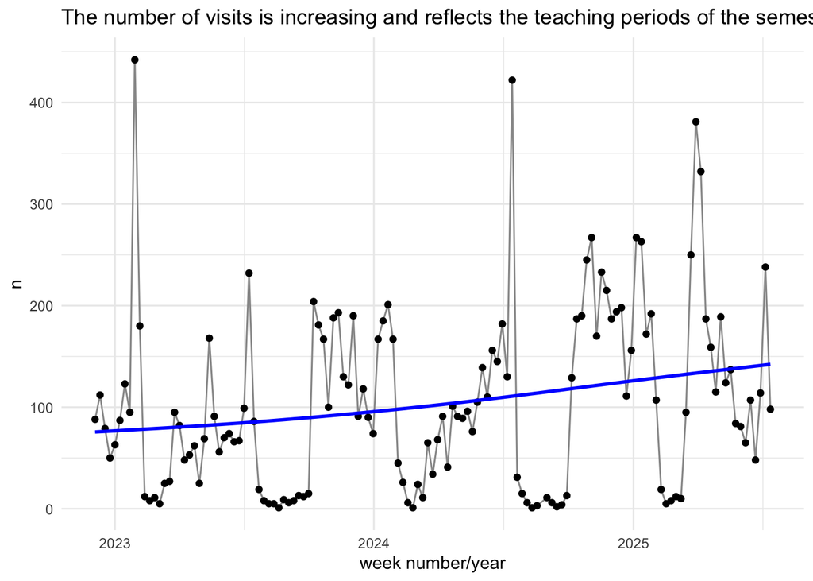

```r
time_visit_wday_summary_week_summarized_dateformat |>
  ggplot(aes(x = week_start, y = n)) +
  geom_line(group = 1, color = "grey60") +
  geom_point() +
  geom_smooth(method = "gam", se = FALSE, color = "blue") +
  labs(
    title = "The number of visits is increasing and reflects the teaching periods of the semesters.",
    x = "week number/year"
  )
```

**Important**

The number of visits has increased over time.

### 5.3.3 Akkumulierte Seitenaufrufe im Zeitverlauf

#### 5.3.3.1 Monat - idvisit

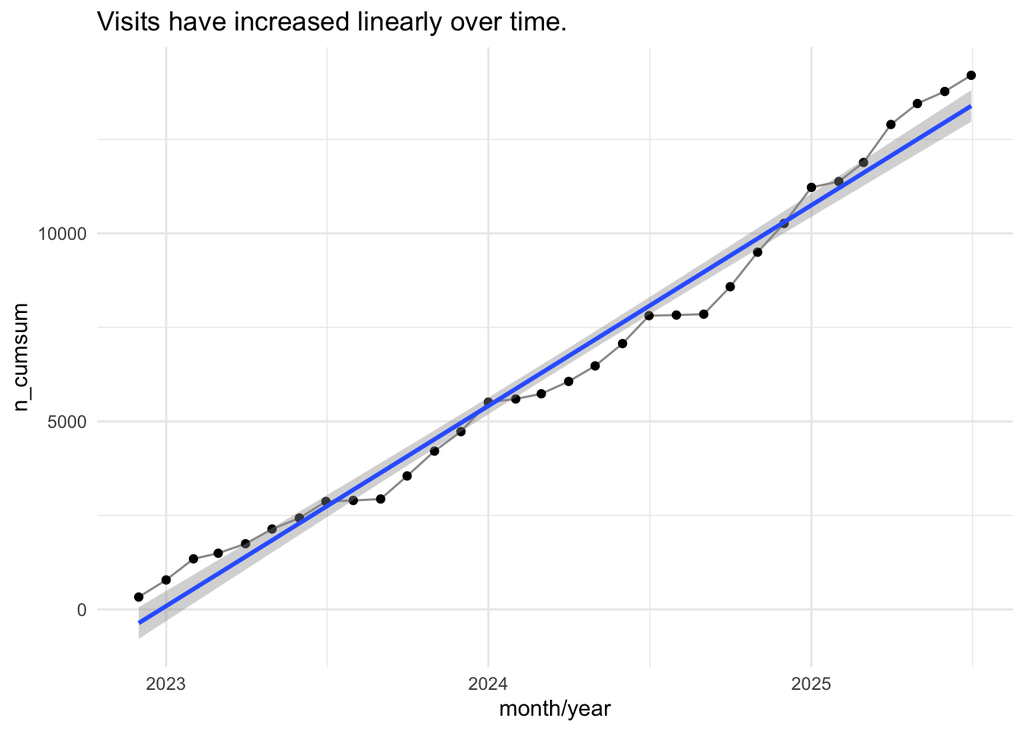

```r
time_visit_wday_summary |>
  group_by(year_num, month_start) |>
  summarise(n = n()) |>
  ungroup() |>
  mutate(n_cumsum = cumsum(n)) |>
  ggplot(aes(x = month_start, y = n_cumsum)) +
  geom_line(group = 1, color = "grey60") +
  geom_point() +
  theme_minimal() +
  geom_smooth(method = "lm") +
  labs(title = "Visits have increased linearly over time.", x = "month/year")
```

#### 5.3.3.2 Monat - fingerprint

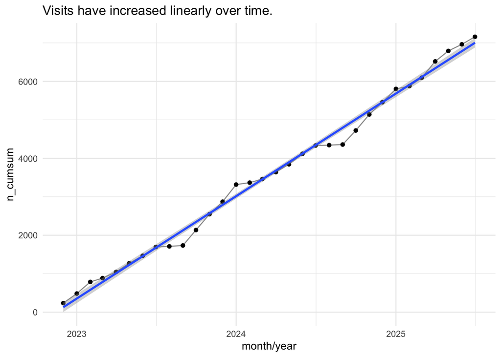

```r
time_visit_wday_summary_fingerprint |>
  group_by(year_num, month_start) |>
  summarise(n = n()) |>
  ungroup() |>
  mutate(n_cumsum = cumsum(n)) |>
  ggplot(aes(x = month_start, y = n_cumsum)) +
  geom_line(group = 1, color = "grey60") +
  geom_point() +
  theme_minimal() +
  geom_smooth(method = "lm") +
  labs(title = "Visits have increased linearly over time.", x = "month/year")
```

#### 5.3.3.3 Monat - fingerprint unique

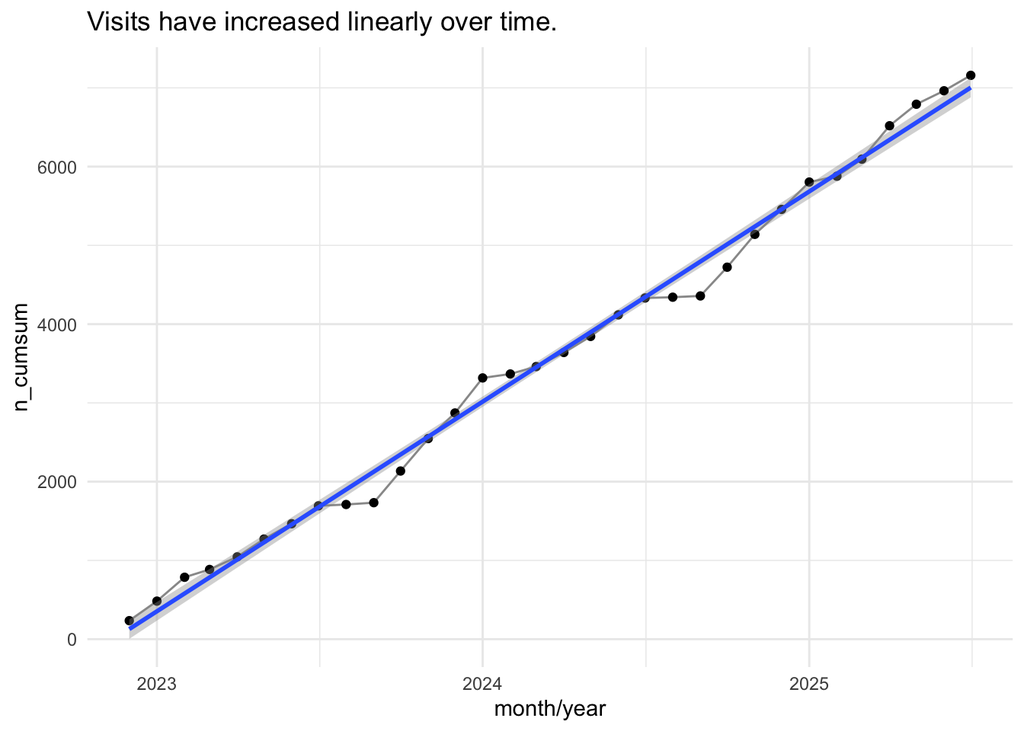

```r
time_visit_wday_summary_fingerprint_unique |>
  group_by(year_num, month_start) |>
  summarise(n = n()) |>
  ungroup() |>
  mutate(n_cumsum = cumsum(n)) |>
  ggplot(aes(x = month_start, y = n_cumsum)) +
  geom_line(group = 1, color = "grey60") +
  geom_point() +
  theme_minimal() +
  geom_smooth(method = "lm") +
  labs(title = "Visits have increased linearly over time.", x = "month/year")
```

#### 5.3.3.4 Woche

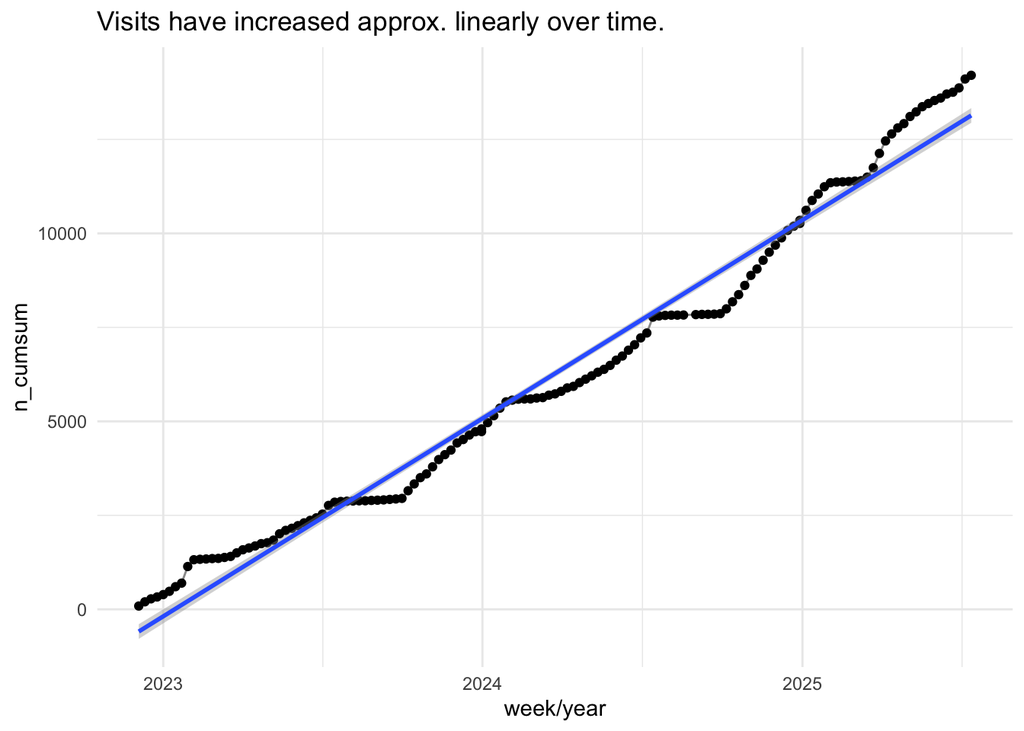

```r
time_visit_wday_summary_week |>
  group_by(year_num, week_start) |>
  summarise(n = n()) |>
  ungroup() |>
  mutate(n_cumsum = cumsum(n)) |>
  ggplot(aes(x = week_start, y = n_cumsum)) +
  geom_line(group = 1, color = "grey60") +
  geom_point() +
  theme_minimal() +
  geom_smooth(method = "lm") +
  labs(
    title = "Visits have increased approx. linearly over time.",
    x = "week/year"
  )
```

## 5.4 Statistiken

Die folgenden Statistiken beruhen auf dem Datensatz `data_separated_filtered`:

### 5.4.1 idivisit

```r
glimpse(data_separated_filtered)
```

```
Rows: 4,477,584
Columns: 5
$ nr          <int> 0, 0, 1, 1, 1, 1, 2, 2, 3, 3, 3, 3, 4, 4, 4, 4, 5, 5, 5, 5…
$ type        <fct> subtitle, timestamp, eventcategory, eventaction, timestamp…
$ value       <fct> "https://hans.th-nuernberg.de/", "2023-03-23 18:37:56", "c…
$ idvisit     <int> 1, 1, 1, 1, 1, 1, 1, 1, 1, 1, 1, 1, 1, 1, 1, 1, 1, 1, 1, 1…
$ fingerprint <fct> aa8a78771b4f21ff, aa8a78771b4f21ff, aa8a78771b4f21ff, aa8a…
```

`nr` fasst die Nummer der Aktion innerhalb eines bestimmten Visits.

### 5.4.2 fingerprint unique

```r
data_separated_filtered |>
  distinct(fingerprint, .keep_all = TRUE) |>
  glimpse()
```

```
Rows: 7,160
Columns: 5
$ nr          <int> 0, 0, 0, 0, 0, 0, 0, 0, 0, 0, 0, 0, 0, 0, 0, 0, 0, 0, 0, 0…
$ type        <fct> subtitle, subtitle, subtitle, subtitle, subtitle, subtitle…
$ value       <fct> "https://hans.th-nuernberg.de/", "https://hans.th-nuernber…
$ idvisit     <int> 1, 3, 6, 7, 8, 10, 15, 16, 17, 18, 19, 20, 21, 22, 23, 24,…
$ fingerprint <fct> aa8a78771b4f21ff, 1f026ad3cbbdf325, 518965d4e1ae7e2d, aa95…
```

## 5.5 Mit allen Daten (den 499er-Daten)

### 5.5.1 idvisit

```r
tbl_n_action <-
  n_action |>
  describe_distribution(nr_max, centrality = c("median", "mean"))

tbl_n_action
```

| Variable | Median | MAD | Mean | SD | IQR | Min | Max | Skewness | Kurtosis | n | n_Missing |
| --- | --- | --- | --- | --- | --- | --- | --- | --- | --- | --- | --- |
| nr_max | 27 | 37.065 | 79.75202 | 122.5267 | 88 | 1 | 499 | 2.23625 | 4.40704 | 14207 | 0 |

[figure not shown]

`nr_max` gibt den Maximalwert von `nr` zurück, sagt also, wie viele Aktionen maximal während eines Vitis ausgeführt wurden.

Betrachtet man die Anzahl der Aktionen pro Visit näher, so fällt auf, dass der Maximalwert (499) sehr häufig vorkommt:

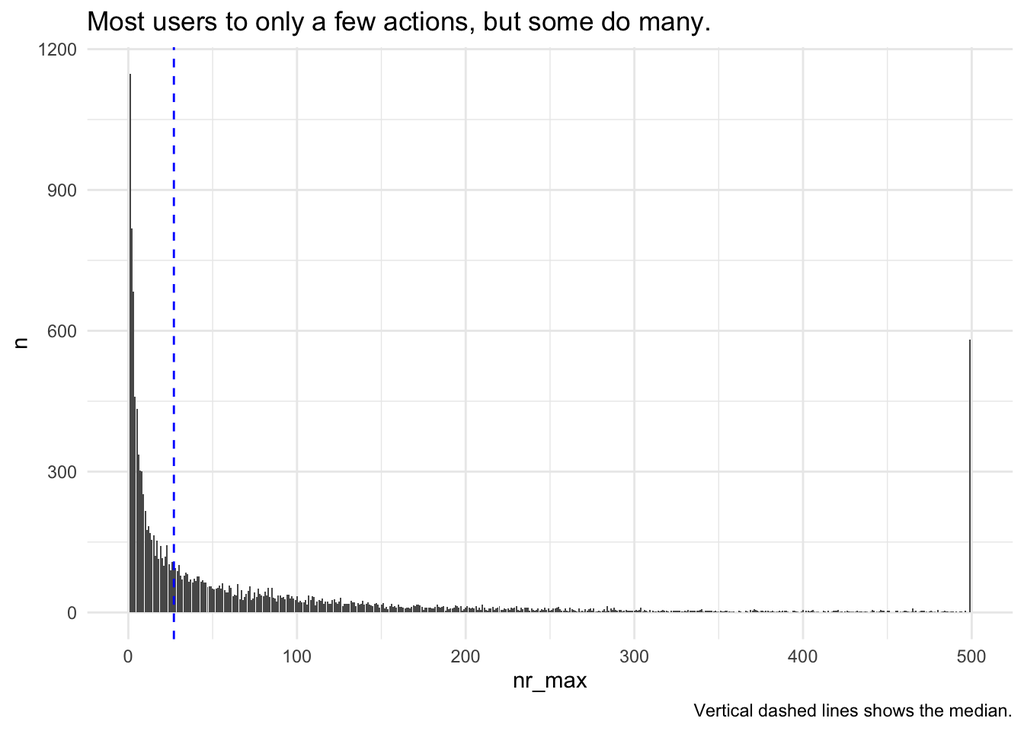

```r
n_action |>
  count(nr_max) |>
  ggplot(aes(x = nr_max, y = n)) +
  geom_col() +
  geom_vline(
    xintercept = tbl_n_action$Median,
    color = "blue",
    linetype = "dashed"
  ) +
  labs(
    caption = "Vertical dashed lines shows the median.",
    title = "Most users to only a few actions, but some do many."
  )
```

**Important**

Die meisten Nutzer machen nur wenige Aktionen pro Visit, aber einige machen sehr viele.

Hier noch in einer anderen Darstellung:

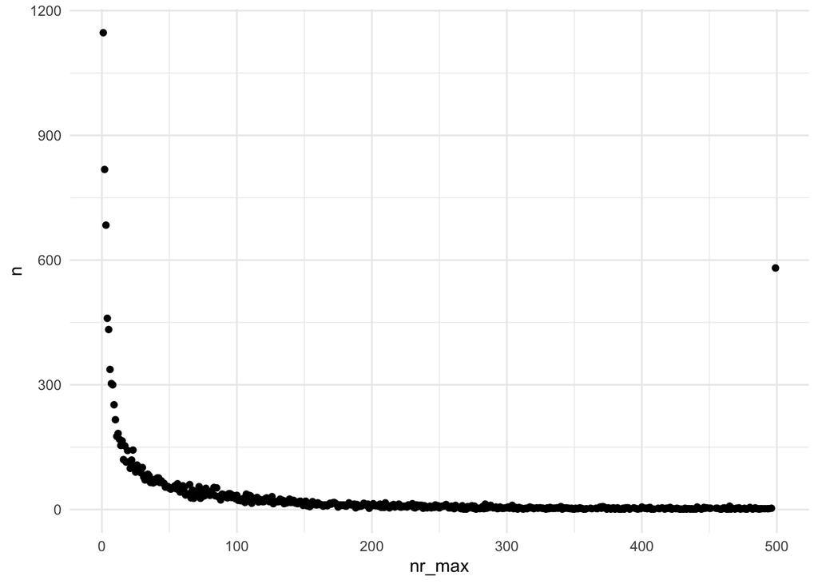

```r
n_action |>
  count(nr_max) |>
  ggplot(aes(x = nr_max, y = n)) +
  geom_point()
```

Der Maximalwert ist einfach auffällig häufig:

```r
n_action |>
  count(nr_max == 499) |>
  gt()
```

| nr_max == 499 | n |
| --- | --- |
| FALSE | 13626 |
| TRUE | 581 |

Es erscheint plausibel, dass der Maximalwert alle “gekappten” (*zensierten*, abgeschnittenen) Werte fasst, also viele Werte, die eigentlich größer wären (aber dann zensiert wurden).

### 5.5.2 fingerprint

```r
tbl_n_action_fingerprint <-
  n_action_fingerprint |>
  describe_distribution(nr_max, centrality = c("median", "mean"))

tbl_n_action_fingerprint
```

| Variable | Median | MAD | Mean | SD | IQR | Min | Max | Skewness | Kurtosis | n | n_Missing |
| --- | --- | --- | --- | --- | --- | --- | --- | --- | --- | --- | --- |
| nr_max | 38 | 51.891 | 98.775 | 136.419 | 119 | 1 | 499 | 1.807791 | 2.351025 | 7160 | 0 |

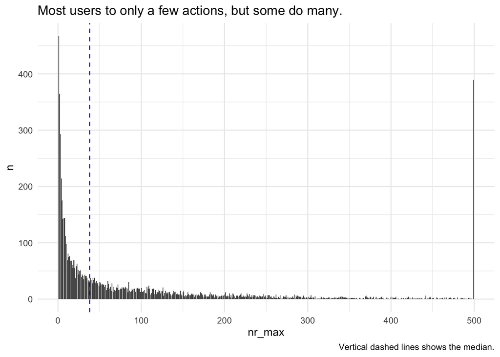

```r
n_action_fingerprint |>
  count(nr_max) |>
  ggplot(aes(x = nr_max, y = n)) +
  geom_col() +
  geom_vline(
    xintercept = tbl_n_action_fingerprint$Median,
    color = "blue",
    linetype = "dashed"
  ) +
  labs(
    caption = "Vertical dashed lines shows the median.",
    title = "Most users to only a few actions, but some do many."
  )
```

### 5.5.3 fingerprint unique

```r
tbl_n_action_fingerprint_unique <-
  n_action_fingerprint |>
  distinct(fingerprint, .keep_all = TRUE)

tbl_n_action_fingerprint_unique |>
  describe_distribution(nr_max, centrality = c("median", "mean"))
```

| Variable | Median | MAD | Mean | SD | IQR | Min | Max | Skewness | Kurtosis | n | n_Missing |
| --- | --- | --- | --- | --- | --- | --- | --- | --- | --- | --- | --- |
| nr_max | 38 | 51.891 | 98.775 | 136.419 | 119 | 1 | 499 | 1.807791 | 2.351025 | 7160 | 0 |

[figure not shown]

```r
tbl_n_action_fingerprint_unique |>
  count(nr_max) |>
  ggplot(aes(x = nr_max, y = n)) +
  geom_col() +
  geom_vline(
    xintercept = tbl_n_action_fingerprint_unique$Median,
    color = "blue",
    linetype = "dashed"
  ) +
  labs(
    caption = "Vertical dashed lines shows the median.",
    title = "Most users to only a few actions, but some do many."
  )
```

## 5.6 Nur Visitors, für die weniger als 500 Aktionen protokolliert sind

### 5.6.1 idvisit

```r
n_action_lt_500 <-
  n_action |>
  filter(nr_max != 499)

n_action_lt_500 |>
  describe_distribution(nr_max) |>
  gt() |>
  fmt_number(columns = where(is.numeric), decimals = 2)
```

| Variable | Mean | SD | IQR | Min | Max | Skewness | Kurtosis | n | n_Missing |
| --- | --- | --- | --- | --- | --- | --- | --- | --- | --- |
| nr_max | 61.88 | 88.53 | 77.00 | 1.00 | 496.00 | 2.27 | 5.47 | 13,626.00 | 0.00 |

### 5.6.2 fingerprint

```r
n_action_lt_500_fingerprint <-
  n_action_fingerprint |>
  filter(nr_max != 499)

n_action_lt_500_fingerprint |>
  describe_distribution(nr_max) |>
  gt() |>
  fmt_number(columns = where(is.numeric), decimals = 2)
```

| Variable | Mean | SD | IQR | Min | Max | Skewness | Kurtosis | n | n_Missing |
| --- | --- | --- | --- | --- | --- | --- | --- | --- | --- |
| nr_max | 75.78 | 99.73 | 100.00 | 1.00 | 496.00 | 1.88 | 3.31 | 6,771.00 | 0.00 |

### 5.6.3 fingerprint unique

```r
n_action_lt_500_fingerprint_unique <-
  n_action_fingerprint |>
  filter(nr_max != 499) |>
  distinct(fingerprint, .keep_all = TRUE)

n_action_lt_500_fingerprint_unique |>
  describe_distribution(nr_max) |>
  gt() |>
  fmt_number(columns = where(is.numeric), decimals = 2)
```

| Variable | Mean | SD | IQR | Min | Max | Skewness | Kurtosis | n | n_Missing |
| --- | --- | --- | --- | --- | --- | --- | --- | --- | --- |
| nr_max | 75.78 | 99.73 | 100.00 | 1.00 | 496.00 | 1.88 | 3.31 | 6,771.00 | 0.00 |

# 6 Lehrveranstaltungen

## 6.1 Anzahl an Lehrveranstaltungen nach Hochschule

### 6.1.1 idvisit

```r
course_and_uni_per_visit |>
  count(university)
```

| university | n |
| --- | --- |
| evhn | 6 |
| hnu | 13 |
| hs-ansbach | 3 |
| hswt | 1109 |
| iqw | 1 |
| th-nuernberg | 4262 |
| th-owl | 1 |
| thi | 440 |
| NA | 8372 |

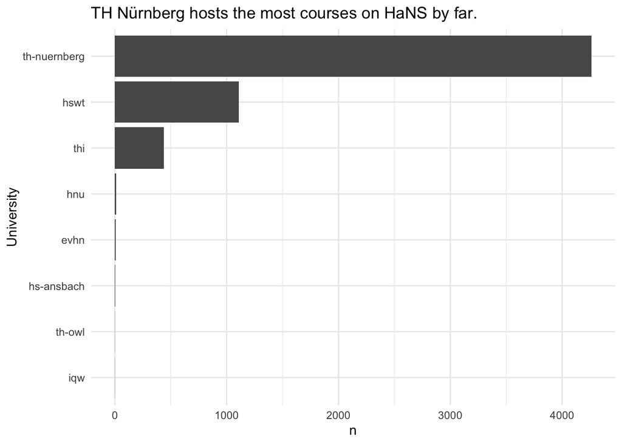

```r
course_and_uni_per_visit |>
  count(university) |>
  drop_na() |>
  ggplot(aes(y = reorder(university, n), x = n)) +
  geom_col() +
  theme_minimal() +
  labs(
    title = "TH Nürnberg hosts the most courses on HaNS by far.",
    y = "University"
  )
```

### 6.1.2 fingerprint unique

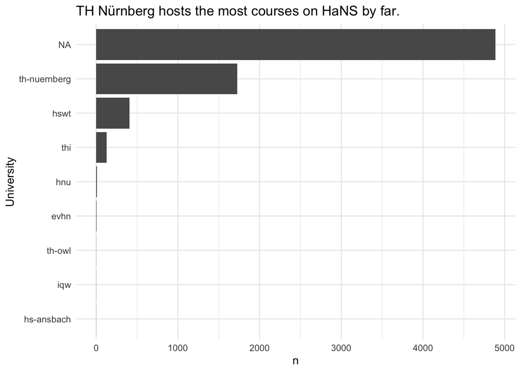

```r
course_and_uni_per_visit |>
  distinct(fingerprint, .keep_all = TRUE) |>
  count(university) |>
  ggplot(aes(y = reorder(university, n), x = n)) +
  geom_col() +
  theme_minimal() +
  labs(
    title = "TH Nürnberg hosts the most courses on HaNS by far.",
    y = "University"
  )
```

## 6.2 Visits nach Lehrveranstaltung und Jahr

### 6.2.1 idvisit

```r
time_spent_w_course_university |>
  count(year, course)
```

| year | course | n |
| --- | --- | --- |
| 2022 | NA | 329 |
| 2023 | NA | 4400 |
| 2024 | anis2 | 42 |
| 2024 | armeufa | 2 |
| 2024 | bare | 4 |
| 2024 | bio | 163 |
| 2024 | biotech | 127 |
| 2024 | biovete | 136 |
| 2024 | cta1 | 264 |
| 2024 | daba | 196 |

[output cut: 42 more lines]

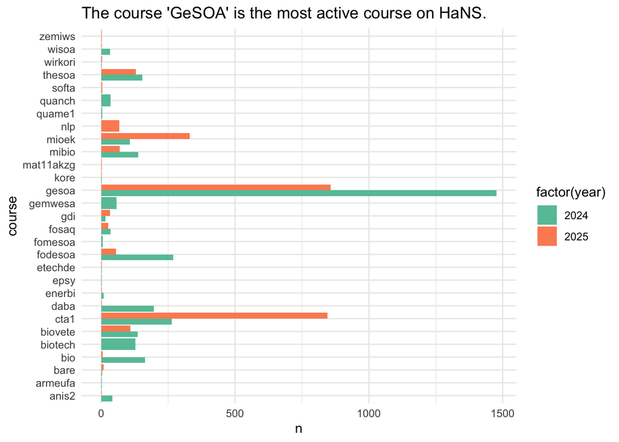

```r
time_spent_w_course_university |>
  count(year, course) |>
  drop_na() |>
  ggplot(aes(x = n, y = course, fill = factor(year), )) +
  geom_col(position = "dodge") +
  labs(title = "The course 'GeSOA' is the most active course on HaNS.")
```

### 6.2.2 fingerprint unique

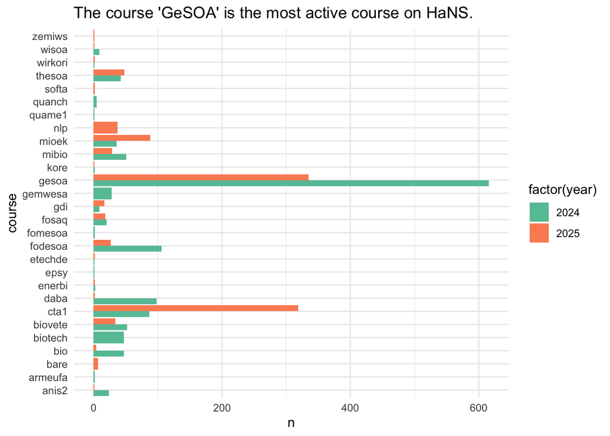

```r
time_spent_w_course_university |>
  distinct(fingerprint, .keep_all = TRUE) |>
  count(year, course) |>
  drop_na() |>
  ggplot(aes(x = n, y = course, fill = factor(year), )) +
  geom_col(position = "dodge") +
  labs(title = "The course 'GeSOA' is the most active course on HaNS.")
```

# 7 Aktionen pro Visit/Fingerprint

## 7.1 Statistiken pro Visit

```r
n_actions_searches_interactions <-
  data_prepped |>
  select(
    idvisit,
    fingerprint,
    any_of(c(
      "searches",
      "actions",
      "interactions",
      "referrertype",
      "referrername",
      "language",
      "devicetype",
      "devicemodel",
      "operatingsystem",
      "browsername"
    ))
  )
```

### 7.1.1 Unique IDs, Fingerprints, Mean searches, Mean actions

Auswertung - der Anzahlen der uniquen visitids und uniquen Fingerprints - Mittelwerte der Anzahl der Suchen und Aktionen pro Besuch

#### 7.1.1.1 idivisit und fingerprint jeweils unique

```r
n_actions_searches_interactions |>
  as.data.frame() |>
  summarise(
    idvisit_n = length(unique(idvisit)),
    fingerprint_n = length(unique(fingerprint)),
    actions_mean = mean(as.integer(actions), na.rm = TRUE),
    searches_mean = mean(as.integer(searches), na.rm = TRUE)
  )
```

| idvisit_n | fingerprint_n | actions_mean | searches_mean |
| --- | --- | --- | --- |
| 14207 | 7160 | 153.0122 | 0.5026395 |

**Note**

Es gibt etwa doppelt so viele Besucher wie unique Nutzer.

### 7.1.2 Referrer Type pro Visit

```r
n_actions_searches_interactions |>
  count(referrertype, sort = TRUE)
```

| referrertype | n |
| --- | --- |
| website | 9387 |
| direct | 4792 |
| search | 19 |
| social | 9 |

### 7.1.3 Referrer Type Name pro Visit

```r
n_actions_searches_interactions |>
  count(referrername, sort = TRUE)
```

| referrername | n |
| --- | --- |
| elearning.ohmportal.de | 7556 |
| NA | 4792 |
| moodle.hswt.de | 1242 |
| moodle.thi.de | 259 |
| my.ohmportal.de | 96 |
| ohmportal.de | 47 |
| statics.teams.cdn.office.net | 32 |
| hans.th-nuernberg.de | 23 |
| moodle.didaktikzentrum.de | 23 |
| elarch.cs.ohmportal.de | 21 |

[output cut: 21 more lines]

### 7.1.4 devicemodel

```r
n_actions_searches_interactions |>
  count(devicemodel, sort = TRUE) |>
  slice_head(n = 10)
```

| devicemodel | n |
| --- | --- |
| Generic Desktop | 12375 |
| iPad | 542 |
| iPhone | 467 |
| Generic Mobile device | 104 |
| Galaxy Tab S7 FE 12.4"" WiFi | 51 |
| Generic Smartphone | 32 |
| Galaxy Tab S6 Lite 10.4"" WiFi | 24 |
| Unknown | 21 |
| Galaxy M33 5G | 19 |
| Galaxy Tab A9+ 11.0"" | 19 |

### 7.1.5 operatingsystem

```r
n_actions_searches_interactions |>
  count(operatingsystem, sort = TRUE) |>
  slice_head(n = 10)
```

| operatingsystem | n |
| --- | --- |
| Windows 10 | 4648 |
| Mac 10.15 | 4645 |
| Windows 11 | 2588 |
| Android 14.0 | 261 |
| GNU/Linux | 211 |
| Android 13.0 | 159 |
| iOS 18.3 | 147 |
| iOS 17.5 | 105 |
| iOS 17.6 | 101 |
| iOS 18.5 | 85 |

### 7.1.6 browsername

```r
n_actions_searches_interactions |>
  count(browsername, sort = TRUE) |>
  slice_head(n = 10)
```

| browsername | n |
| --- | --- |
| Safari | 4226 |
| Chrome | 3153 |
| Firefox | 2393 |
| Microsoft Edge | 2361 |
| Mobile Safari | 811 |
| Chrome Mobile | 218 |
| Opera GX | 190 |
| Chrome Mobile iOS | 158 |
| Chrome Webview | 143 |
| Samsung Browser | 142 |

## 7.2 Aktionen pro idvisit/fingerprint - Mit den 499er-Daten

### 7.2.1 idvisit

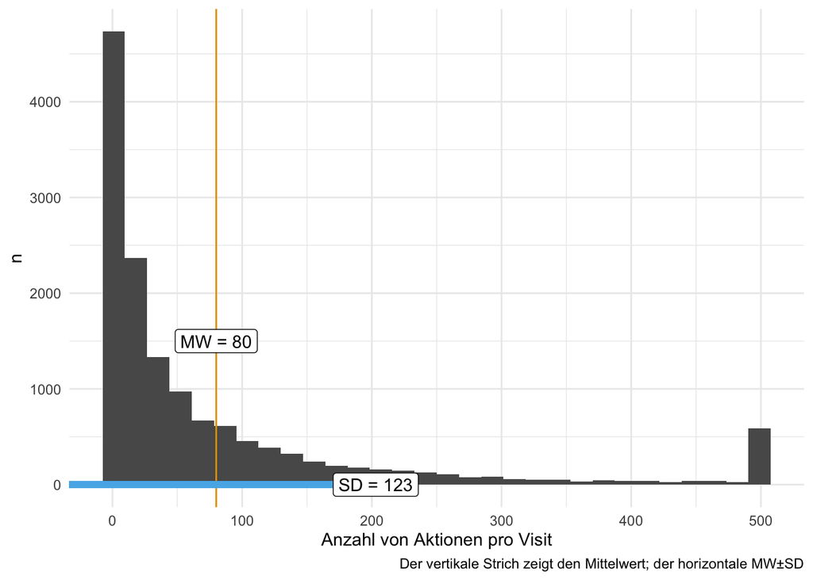

```r
n_action_avg = mean(n_action$nr_max) |> round(0)
n_action_median = median(n_action$nr_max) |> round(0)
n_action_sd = sd(n_action$nr_max) |> round(0)
n_action_iqr = IQR(n_action$nr_max) |> round(0)

n_action |>
  ggplot() +
  geom_histogram(aes(x = nr_max)) +
  labs(
    x = "Anzahl von Aktionen pro Visit",
    y = "n",
    caption = "Der vertikale Strich zeigt den Mittelwert; der horizontale MW±SD"
  ) +
  theme_minimal() +
  geom_vline(xintercept = n_action_avg, color = palette_okabe_ito()[1]) +
  geom_segment(
    x = n_action_avg - n_action_sd,
    y = 0,
    xend = n_action_avg + n_action_sd,
    yend = 0,
    color = palette_okabe_ito()[2],
    size = 2
  ) +
  annotate(
    "label",
    x = n_action_avg,
    y = 1500,
    label = paste0("MW = ", n_action_avg)
  ) +
  annotate(
    "label",
    x = n_action_avg + n_action_sd,
    y = 0,
    label = paste0("SD = ", n_action_sd)
  )
```

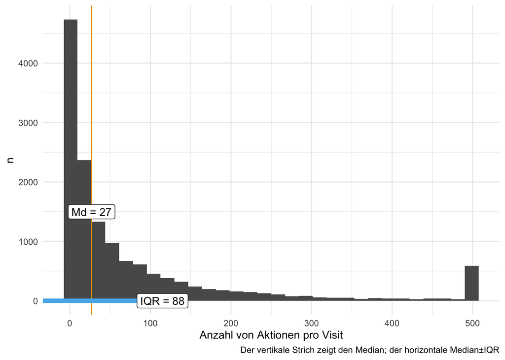

```r
#geom_label(aes(x = n_action_avg), y = 1, label = "Mean")

n_action |>
  ggplot() +
  geom_histogram(aes(x = nr_max)) +
  labs(
    x = "Anzahl von Aktionen pro Visit",
    y = "n",
    caption = "Der vertikale Strich zeigt den Median; der horizontale Median±IQR"
  ) +
  theme_minimal() +
  geom_vline(xintercept = n_action_median, color = palette_okabe_ito()[1]) +
  geom_segment(
    x = n_action_median - n_action_iqr,
    y = 0,
    xend = n_action_median + n_action_iqr,
    yend = 0,
    color = palette_okabe_ito()[2],
    size = 2
  ) +
  annotate(
    "label",
    x = n_action_median,
    y = 1500,
    label = paste0("Md = ", n_action_median)
  ) +
  annotate(
    "label",
    x = n_action_median + n_action_iqr,
    y = 0,
    label = paste0("IQR = ", n_action_iqr)
  )
```

```r
#geom_label(aes(x = n_action_avg), y = 1, label = "Mean")
```

- Mittelwert der Aktionen pro Visit: 80.
- SD der Aktionen pro Visit: 123.
- MD: 27.
- IQR: : 88.

### 7.2.2 fingerprint

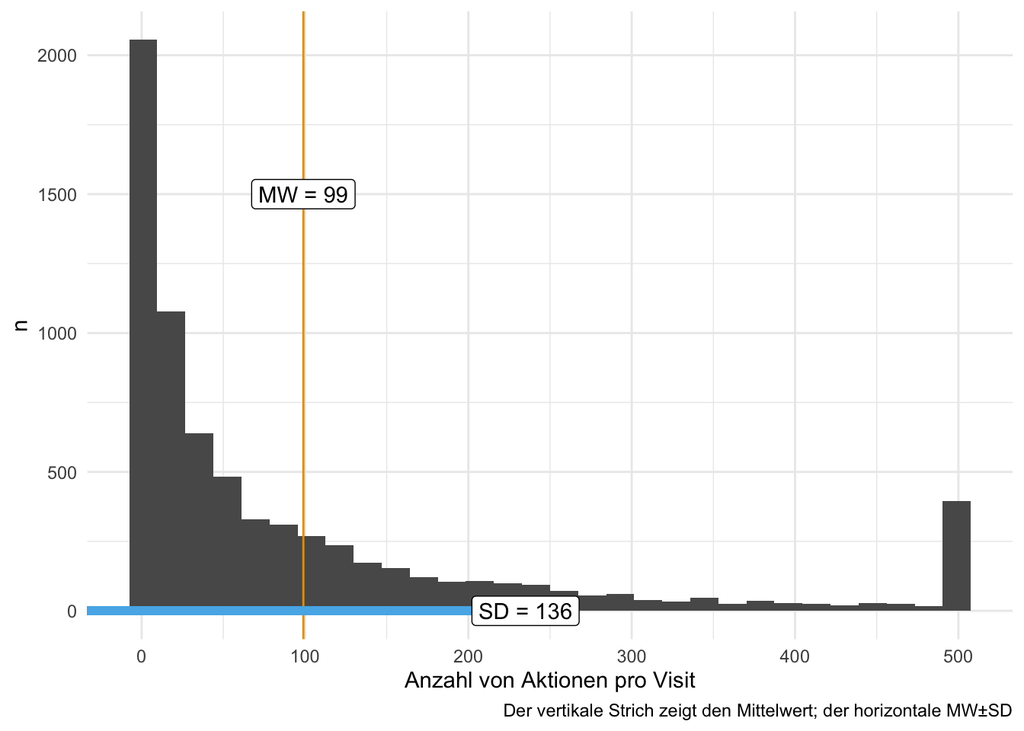

```r
n_action_fingerprint_avg = mean(n_action_fingerprint$nr_max) |> round(0)
n_action_fingerprint_median = median(n_action_fingerprint$nr_max) |> round(0)
n_action_fingerprint_sd = sd(n_action_fingerprint$nr_max) |> round(0)
n_action_fingerprint_iqr = IQR(n_action_fingerprint$nr_max) |> round(0)

n_action_fingerprint |>
  ggplot() +
  geom_histogram(aes(x = nr_max)) +
  labs(
    x = "Anzahl von Aktionen pro Visit",
    y = "n",
    caption = "Der vertikale Strich zeigt den Mittelwert; der horizontale MW±SD"
  ) +
  theme_minimal() +
  geom_vline(
    xintercept = n_action_fingerprint_avg,
    color = palette_okabe_ito()[1]
  ) +
  geom_segment(
    x = n_action_fingerprint_avg - n_action_fingerprint_sd,
    y = 0,
    xend = n_action_fingerprint_avg + n_action_fingerprint_sd,
    yend = 0,
    color = palette_okabe_ito()[2],
    size = 2
  ) +
  annotate(
    "label",
    x = n_action_fingerprint_avg,
    y = 1500,
    label = paste0("MW = ", n_action_fingerprint_avg)
  ) +
  annotate(
    "label",
    x = n_action_fingerprint_avg + n_action_fingerprint_sd,
    y = 0,
    label = paste0("SD = ", n_action_fingerprint_sd)
  )
```

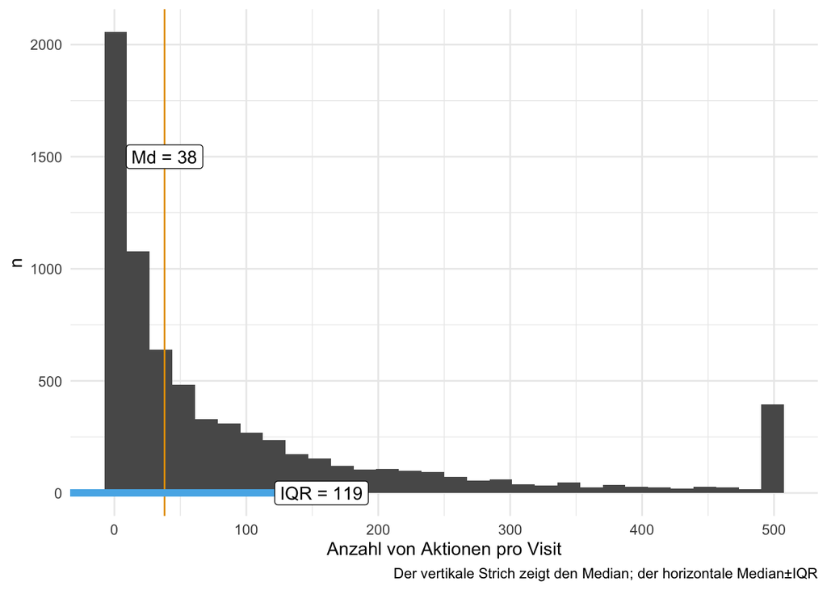

```r
#geom_label(aes(x = n_action_fingerprint_avg), y = 1, label = "Mean")

n_action_fingerprint |>
  ggplot() +
  geom_histogram(aes(x = nr_max)) +
  labs(
    x = "Anzahl von Aktionen pro Visit",
    y = "n",
    caption = "Der vertikale Strich zeigt den Median; der horizontale Median±IQR"
  ) +
  theme_minimal() +
  geom_vline(
    xintercept = n_action_fingerprint_median,
    color = palette_okabe_ito()[1]
  ) +
  geom_segment(
    x = n_action_fingerprint_median - n_action_fingerprint_iqr,
    y = 0,
    xend = n_action_fingerprint_median + n_action_fingerprint_iqr,
    yend = 0,
    color = palette_okabe_ito()[2],
    size = 2
  ) +
  annotate(
    "label",
    x = n_action_fingerprint_median,
    y = 1500,
    label = paste0("Md = ", n_action_fingerprint_median)
  ) +
  annotate(
    "label",
    x = n_action_fingerprint_median + n_action_fingerprint_iqr,
    y = 0,
    label = paste0("IQR = ", n_action_fingerprint_iqr)
  )
```

```r
#geom_label(aes(x = n_action_fingerprint_avg), y = 1, label = "Mean")
```

## 7.3 Ohne 499er-Daten

### 7.3.1 idvisit

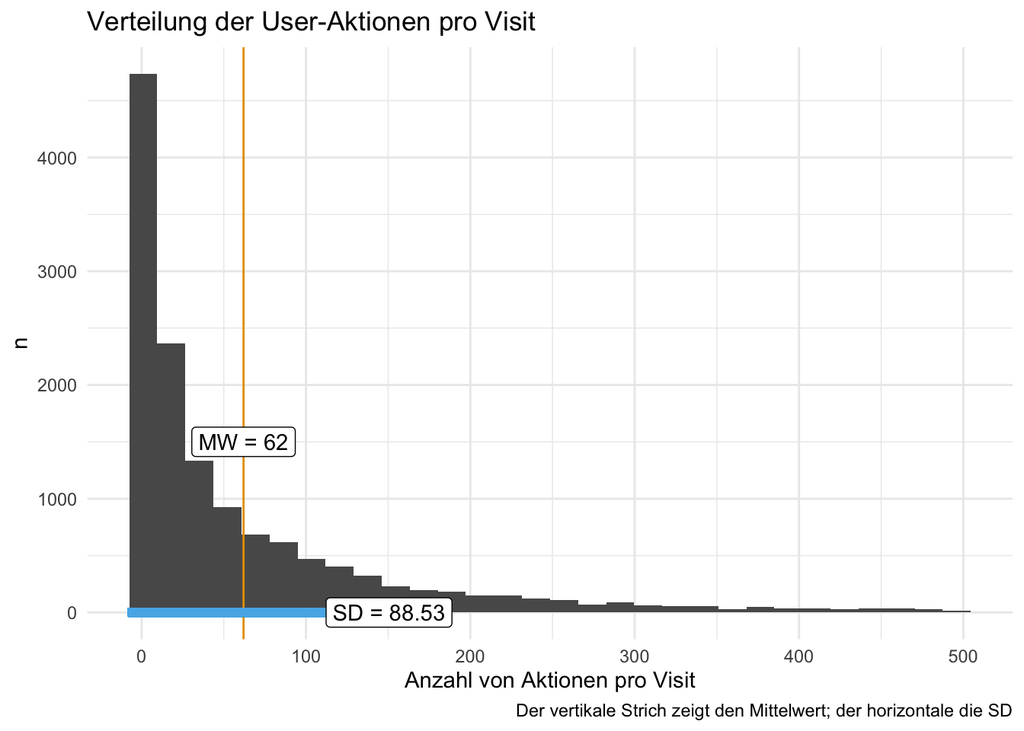

```r
n_action_avg2 = mean(n_action_lt_500$nr_max) |> round(0)
n_action_sd2 = sd(n_action_lt_500$nr_max) |> round(2)

n_action_lt_500 |>
  ggplot() +
  geom_histogram(aes(x = nr_max)) +
  labs(
    x = "Anzahl von Aktionen pro Visit",
    y = "n",
    title = "Verteilung der User-Aktionen pro Visit",
    caption = "Der vertikale Strich zeigt den Mittelwert; der horizontale die SD"
  ) +
  theme_minimal() +
  geom_vline(xintercept = n_action_avg2, color = palette_okabe_ito()[1]) +
  geom_segment(
    x = n_action_avg - n_action_sd2,
    y = 0,
    xend = n_action_avg2 + n_action_sd2,
    yend = 0,
    color = palette_okabe_ito()[2],
    size = 2
  ) +
  annotate(
    "label",
    x = n_action_avg2,
    y = 1500,
    label = paste0("MW = ", n_action_avg2)
  ) +
  annotate(
    "label",
    x = n_action_avg2 + n_action_sd2,
    y = 0,
    label = paste0("SD = ", n_action_sd2)
  )
```

```r
#geom_label(aes(x = n_action_avg), y = 1, label = "Mean")
```

- Mittelwert der Aktionen pro Visit: 62.
- SD der Aktionen pro Visit: 88.53.

### 7.3.2 fingerprint unique

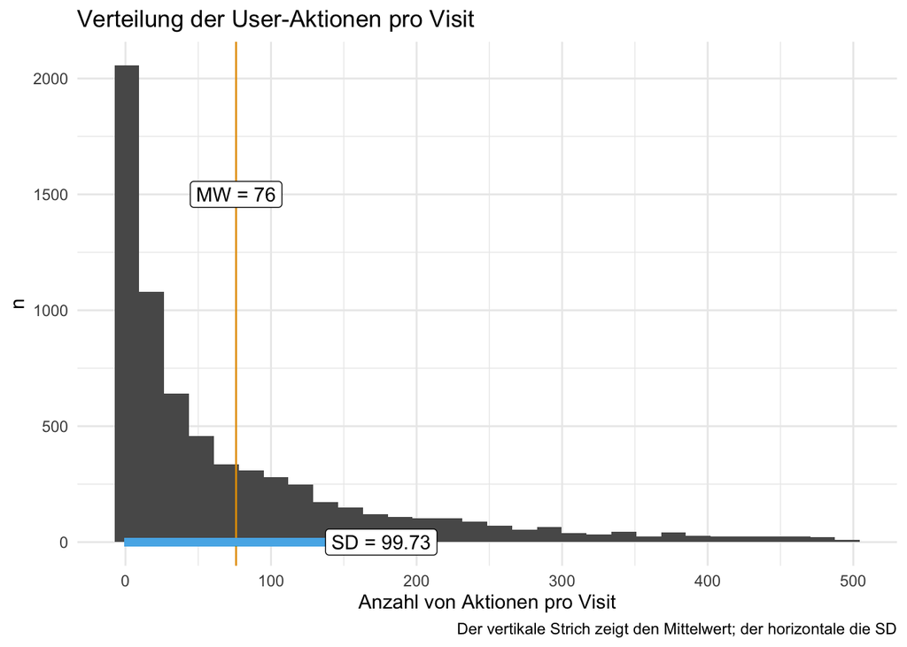

```r
n_action_fingerprint_avg2 = mean(n_action_lt_500_fingerprint_unique$nr_max) |>
  round(0)
n_action_fingerprint_sd2 = sd(n_action_lt_500_fingerprint_unique$nr_max) |>
  round(2)

n_action_lt_500_fingerprint_unique |>
  ggplot() +
  geom_histogram(aes(x = nr_max)) +
  labs(
    x = "Anzahl von Aktionen pro Visit",
    y = "n",
    title = "Verteilung der User-Aktionen pro Visit",
    caption = "Der vertikale Strich zeigt den Mittelwert; der horizontale die SD"
  ) +
  theme_minimal() +
  geom_vline(
    xintercept = n_action_fingerprint_avg2,
    color = palette_okabe_ito()[1]
  ) +
  geom_segment(
    x = n_action_fingerprint_avg - n_action_fingerprint_sd2,
    y = 0,
    xend = n_action_fingerprint_avg2 + n_action_fingerprint_sd2,
    yend = 0,
    color = palette_okabe_ito()[2],
    size = 2
  ) +
  annotate(
    "label",
    x = n_action_fingerprint_avg2,
    y = 1500,
    label = paste0("MW = ", n_action_fingerprint_avg2)
  ) +
  annotate(
    "label",
    x = n_action_fingerprint_avg2 + n_action_fingerprint_sd2,
    y = 0,
    label = paste0("SD = ", n_action_fingerprint_sd2)
  )
```

```r
#geom_label(aes(x = n_action_avg), y = 1, label = "Mean")
```

## 7.4 Anzahl Aktionen im Zeitverlauf

### 7.4.1 Monat

#### 7.4.1.1 idvisit

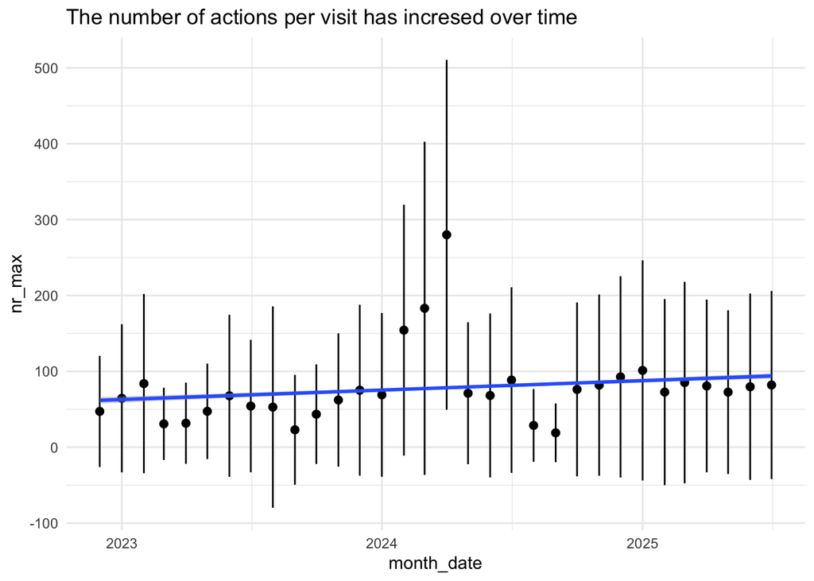

```r
n_action_w_date |>
  ggplot(aes(x = month_date, y = nr_max)) +
  stat_summary(fun = mean, geom = "point", size = 2) +
  stat_summary(
    fun.data = mean_sdl,
    fun.args = list(mult = 1),
    geom = "errorbar",
    width = 0.2
  ) +
  geom_smooth(method = "lm") +
  labs(title = "The number of actions per visit has incresed over time")
```

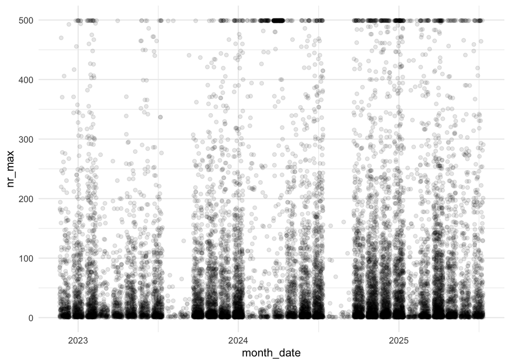

```r
n_action_w_date |>
  ggplot(aes(x = month_date, y = nr_max)) +
  geom_jitter(alpha = .1)
```

#### 7.4.1.2 fingerprint unique

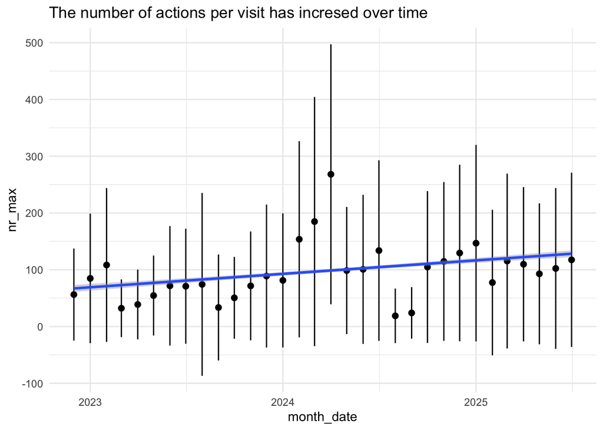

```r
n_action_w_date_fingerprint_unique <-
  n_action_w_date_fingerprint |>
  distinct(fingerprint, .keep_all = TRUE)

n_action_w_date_fingerprint_unique |>
  ggplot(aes(x = month_date, y = nr_max)) +
  stat_summary(fun = mean, geom = "point", size = 2) +
  stat_summary(
    fun.data = mean_sdl,
    fun.args = list(mult = 1),
    geom = "errorbar",
    width = 0.2
  ) +
  geom_smooth(method = "lm") +
  labs(title = "The number of actions per visit has incresed over time")
```

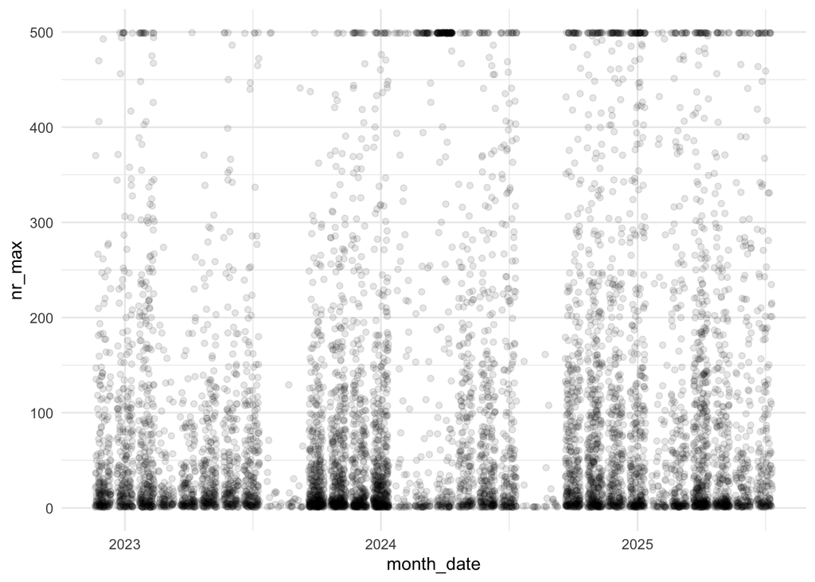

```r
n_action_w_date_fingerprint_unique |>
  ggplot(aes(x = month_date, y = nr_max)) +
  geom_jitter(alpha = .1)
```

### 7.4.2 Regression (Monat)

#### 7.4.2.1 idvisit

```r
lm(nr_max ~ month_date, data = n_action_w_date)
```

```
Call:
lm(formula = nr_max ~ month_date, data = n_action_w_date)

Coefficients:
(Intercept)   month_date
 -5.956e+02    3.937e-07
```

#### 7.4.2.2 fingerprint

```r
lm(nr_max ~ month_date, data = n_action_w_date_fingerprint)
```

```
Call:
lm(formula = nr_max ~ month_date, data = n_action_w_date_fingerprint)

Coefficients:
(Intercept)   month_date
 -1.186e+03    7.503e-07
```

#### 7.4.2.3 fingerprint unique

```r
lm(nr_max ~ month_date, data = n_action_w_date_fingerprint_unique)
```

```
Call:
lm(formula = nr_max ~ month_date, data = n_action_w_date_fingerprint_unique)

Coefficients:
(Intercept)   month_date
 -1.186e+03    7.503e-07
```